# eDNA_data_analysis

Claudia Campanini

2025-07-11

# Load libraries

```r
#if (!require("BiocManager", quietly = TRUE))
  install.packages("BiocManager")

#BiocManager::install("ggtree")

devtools::install_github("GuangchuangYu/ggtree")
```

# Load read abundance data and environmental variable data

```r
#Otu table
Okinawa_Otu <- read_csv(file=here("Multi-taxa_data","eDNA","1-Input_data", "Okinawa_ESV.csv"))
#Tax table
Okinawa_Tax <- read_csv(file=here("Multi-taxa_data","eDNA","1-Input_data","Okinawa_Taxa.csv"))
#environmental data
Okinawa_env <- read_excel(path=here("Multi-taxa_data","eDNA","1-Input_data","Okinawa_ESV_taxon_table_NCsub_4excluded_2_85percent_threshold_metadata_rda.xlsx"))
```

Format data

```r
Okinawa_env$Location <- as.factor(Okinawa_env$Location)
Okinawa_env$depth <- as.factor(Okinawa_env$depth)
Okinawa_env$impact <- as.factor(Okinawa_env$impact)
Okinawa_env$pop_score <- as.factor(Okinawa_env$pop_score)
Okinawa_env$freshwater_input <- as.factor(Okinawa_env$freshwater_input)
Okinawa_env$fishing_pressure <- as.factor(Okinawa_env$fishing_pressure)
Okinawa_env$coast_score <- as.factor(Okinawa_env$coast_score)
Okinawa_env$human_score <- as.factor(Okinawa_env$human_score)
Okinawa_env$herma_score <- as.factor(Okinawa_env$herma_score)
Okinawa_env$other_pressures <- as.factor(Okinawa_env$other_pressures)
```

# TAXONOMIC RANK

Count occurrences of each taxonomic rank

```r
all_counts <- Okinawa_Tax %>%
  count(Phylum, Class, Order, Family, Genus, Species, ID) %>%
  summarise(Phylum = sum(!is.na(Phylum)),
            Class = sum(!is.na(Class)),
            Order = sum(!is.na(Order)),
            Family = sum(!is.na(Family)),
            Genus = sum(!is.na(Genus)),
            Species = sum(!is.na(Species)),
            ESVs = sum(!is.na(ID)))
```

Reshape all counts to long format

```r
# Reshape the data for plotting
all_counts_long <- all_counts %>%
  pivot_longer(cols = everything(), names_to = "Taxonomic rank", values_to = "Count")

# Define the order of features
feature_order <- c("ESVs", "Phylum", "Class", "Order", "Family", "Genus", "Species")

# Order the bars based on the predefined order
all_counts_long$Feature <- factor(all_counts_long$`Taxonomic rank`, levels = feature_order)
```

Count unique features for each column

```r
unique_counts <- Okinawa_Tax %>%
  summarise(Phylum = n_distinct(Phylum),
            Class = n_distinct(Class),
            Order = n_distinct(Order),
            Family = n_distinct(Family),
            Genus = n_distinct(Genus),
            Species = n_distinct(Species),
            ESVs = n_distinct(ID))
```

Reshape unique counts to long format

```r
# Reshape the data for plotting
unique_counts_long <- unique_counts %>%
  pivot_longer(cols = everything(), names_to = "Taxonomic rank", values_to = "Count")
# Order the bars based on the predefined order

unique_counts_long$Feature <- factor(unique_counts_long$`Taxonomic rank`, levels = feature_order)
```

Total counts

```r
# Combine total and unique counts
combined_counts <- inner_join(all_counts_long, unique_counts_long, by = "Taxonomic rank")
# Reorder the levels of the Taxonomic rank factor
combined_counts$`Taxonomic rank` <- factor(combined_counts$`Taxonomic rank`, levels = feature_order)

# Combine counts into a single data frame
labels_df <- combined_counts %>%
  mutate(label = paste(Count.x, Count.y, sep = "/")) %>%
  select(`Taxonomic rank`, label)
```

Create a stacked bar chart

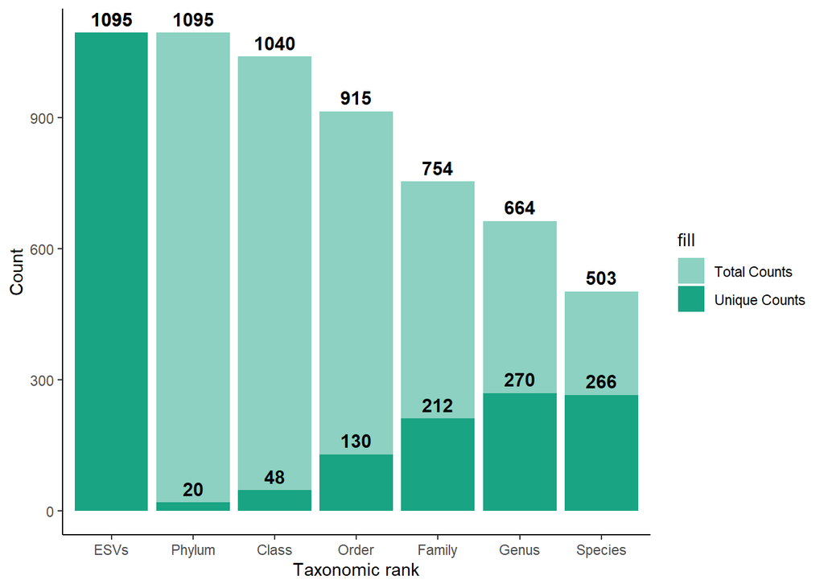

```r
#
combined_counts_bar <- ggplot(combined_counts, aes(x = `Taxonomic rank`)) +
     geom_bar(aes(y = Count.x, fill = "Total Counts"), stat = "identity", alpha = 0.5) +
     geom_bar(aes(y = Count.y, fill = "Unique Counts"), stat = "identity") +
     geom_text(aes(y = Count.x, label = Count.x), vjust = -0.5, size = 4, fontface = "bold") +
     geom_text(aes(y = Count.y, label = Count.y), vjust = -0.5, size = 4, fontface = "bold") +
     scale_fill_manual(values = c("Total Counts" = "#19a483", "Unique Counts" = "#19a483")) +
     labs(x = "Taxonomic rank", y = "Count") +
     theme_classic()
combined_counts_bar
```

Export combined_counts bar plot

```r
ggsave("combined_counts_bar.png",
       plot = combined_counts_bar,
       units ="in", width = 8, height = 6, dpi = 600,
       path = here::here("Multi-taxa_data","eDNA","4-Visualization_outputs"))
```

# ANALYSES WITH PHYLOSEQ

Create otu_table, tax_table and sample_data objects for analyses

```r
esv_mat <- as.matrix(column_to_rownames(Okinawa_Otu, "ID"))
tax_mat <- as.matrix(column_to_rownames(Okinawa_Tax, "ID"))
samples_df <- column_to_rownames(Okinawa_env, "Samples")

ESV = otu_table(esv_mat, taxa_are_rows = TRUE)
TAX = tax_table(tax_mat)
samples = sample_data(samples_df)

Ok <- phyloseq(ESV, TAX, samples)
metadata <- data.frame(sample_data(Ok))

sample_names(Ok)
```

```
##  [1] "CapeZanpa_shallow_seawater_3"    "CapeZanpa_shallow_seawater_2"
##  [3] "CapeZanpa_shallow_seawater_1"    "CapeZanpa_deep_seawater_3"
##  [5] "CapeZanpa_deep_seawater_2"       "CapeZanpa_deep_seawater_1"
##  [7] "Zatsun_shallow_seawater_3"       "Zatsun_shallow_seawater_2"
##  [9] "Zatsun_shallow_seawater_1"       "Zatsun_deep_seawater_3"
## [11] "Zatsun_deep_seawater_2"          "Zatsun_deep_seawater_1"
## [13] "Yonama_shallow_seawater_3"       "Yonama_shallow_seawater_2"
## [15] "Yonama_deep_seawater_1"          "Yonama_deep_seawater_3"
## [17] "Yonama_deep_seawater_2"          "Sunabe_shallow_seawater_3"
## [19] "Sunabe_shallow_seawater_2"       "Sunabe_shallow_seawater_1"
## [21] "Sunabe_deep_seawater_3"          "Sunabe_deep_seawater_2"
## [23] "Sunabe_deep_seawater_1"          "Sukuta_shallow_seawater_3"
## [25] "Sukuta_shallow_seawater_2"       "Sukuta_shallow_seawater_1"
## [27] "Sakubaru2_shallow_seawater_3"    "Sakubaru2_shallow_seawater_1"
## [29] "Sakubaru2_deep_seawater_3"       "Sakubaru2_deep_seawater_2"
```

[output cut: 19 more lines]

```r
sample_variables(Ok)
```

```
##  [1] "Location"         "depth"            "impact"           "pop_score"
##  [5] "freshwater_input" "fishing_pressure" "coast_score"      "human_score"
##  [9] "herma_score"      "other_pressures"
```

```r
head(sample_data(Ok))
```

```
##                               Location   depth impact pop_score
## CapeZanpa_shallow_seawater_3 CapeZanpa shallow medium        -1
## CapeZanpa_shallow_seawater_2 CapeZanpa shallow medium        -1
## CapeZanpa_shallow_seawater_1 CapeZanpa shallow medium        -1
## CapeZanpa_deep_seawater_3    CapeZanpa    deep medium        -1
## CapeZanpa_deep_seawater_2    CapeZanpa    deep medium        -1
## CapeZanpa_deep_seawater_1    CapeZanpa    deep medium        -1
##                              freshwater_input fishing_pressure coast_score
## CapeZanpa_shallow_seawater_3                0             -0.5           0
## CapeZanpa_shallow_seawater_2                0             -0.5           0
## CapeZanpa_shallow_seawater_1                0             -0.5           0
## CapeZanpa_deep_seawater_3                   0             -0.5           0
## CapeZanpa_deep_seawater_2                   0             -0.5           0
## CapeZanpa_deep_seawater_1                   0             -0.5           0
##                              human_score herma_score other_pressures
## CapeZanpa_shallow_seawater_3        -0.5        -0.5               0
## CapeZanpa_shallow_seawater_2        -0.5        -0.5               0
## CapeZanpa_shallow_seawater_1        -0.5        -0.5               0
## CapeZanpa_deep_seawater_3           -0.5        -0.5               0
## CapeZanpa_deep_seawater_2           -0.5        -0.5               0
## CapeZanpa_deep_seawater_1           -0.5        -0.5               0
```

Clean up the taxonomy table to fix empty cells

```r
tax <- data.frame(tax_table(Ok))

tax.clean <- data.frame(row.names = row.names(tax),
                        Phylum = str_replace(tax[,1], "D_1__",""),
                        Class = str_replace(tax[,2], "D_2__",""),
                        Order = str_replace(tax[,3], "D_3__",""),
                        Family = str_replace(tax[,4], "D_4__",""),
                        Genus = str_replace(tax[,5], "D_5__",""),
                        Species = str_replace(tax[,6], "D_6__",""),
                        stringsAsFactors = FALSE)
tax.clean[is.na(tax.clean)] <- ""

for (i in 1:6){ tax.clean[,i] <- as.character(tax.clean[,i])}
tax.clean[is.na(tax.clean)] <- ""
for (i in 1:nrow(tax.clean)){if (tax.clean[i,2] == ""){
  phylum <- paste("Phylum_", tax.clean[i,1], sep = "")
  tax.clean[i, 2:6] <- phylum
} else if (tax.clean[i,3] == ""){
  class <- paste("Class_", tax.clean[i,2], sep = "")
  tax.clean[i, 3:6] <- class
} else if (tax.clean[i,4] == ""){
  order <- paste("Order_", tax.clean[i,3], sep = "")
  tax.clean[i, 4:6] <- order
} else if (tax.clean[i,5] == ""){
  family <- paste("Family_", tax.clean[i,4], sep = "")
  tax.clean[i, 5:6] <- family
} else if (tax.clean[i,6] == ""){
  tax.clean$Species[i] <- paste("Genus",tax.clean$Genus[i], sep = "_")
}
}

tax_table(Ok) <- as.matrix(tax.clean)
View(tax_table(Ok))
```

## Ridgeline plot of relative abundances

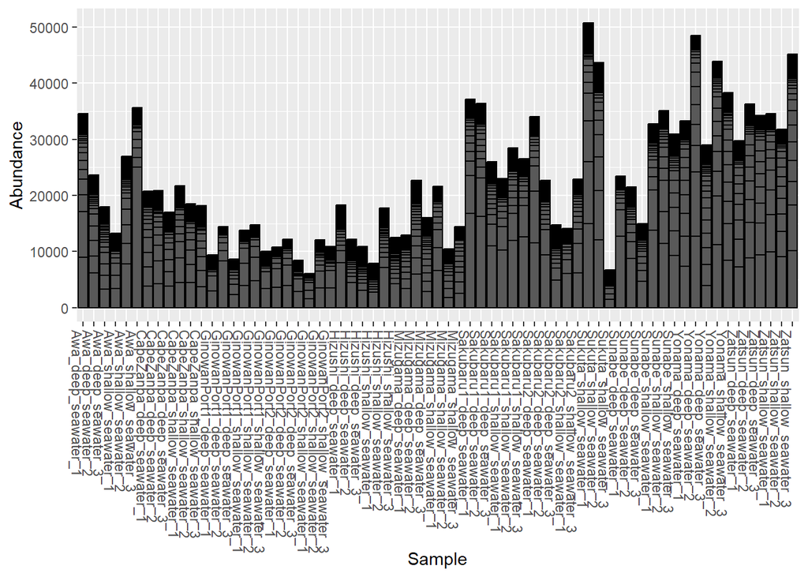

```r
plot_bar(Ok)
```

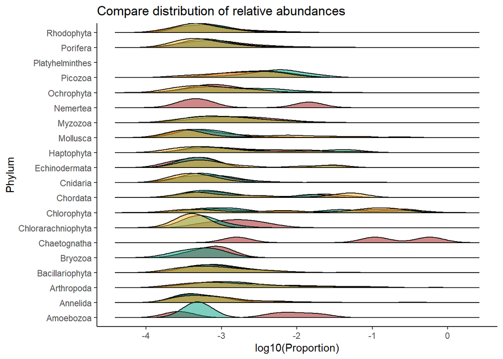

```r
relative_abundance_distribution_ridge <- Ok %>%
  psmelt() %>%
  group_by(Sample) %>%
  mutate(Proportion = Abundance / sum(Abundance, na.rm = TRUE)) %>%
  filter(Proportion > 0) %>%
  filter(!is.na(Phylum)) %>%
  ggplot(aes(y = Phylum, x = log10(Proportion), fill = impact)) +
  scale_fill_manual(values = c(medium = "#FFB331",high = "#9F1111", low = "#009F81")) +
  ggridges::geom_density_ridges2(scale = 1, alpha = 0.5, show.legend = FALSE) +
  ggtitle("Compare distribution of relative abundances") +
  theme_classic()

relative_abundance_distribution_ridge
```

```r
ggsave("relative_abundance_distribution_ridge.png",
       units ="in", width = 8, height = 6, dpi = 300,
       path = here::here("Multi-taxa_data","eDNA","4-Visualization_outputs"))
```

## Bar chart of relative abundances

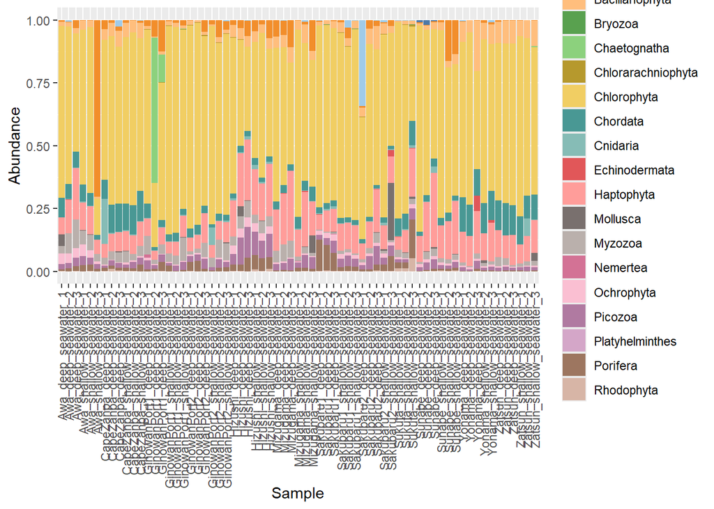

```r
#bar chart relative abundances
Okrel = transform_sample_counts(Ok, function(x) x / sum(x))

Ok2 <- psmelt(Okrel)

ggplot(Ok2, aes(x = Sample, y = Abundance, fill = Phylum)) +
  geom_bar(stat = "identity") +
  paletteer:: scale_fill_paletteer_d("ggthemes::Tableau_20") +  # Using viridis color palette
  labs(x = "Sample", y = "Abundance", fill = "Phylum") +
  theme(axis.text.x = element_text(angle = 90, vjust = 0.5, hjust = 1))
```

## Bar chart ESVs per phyla

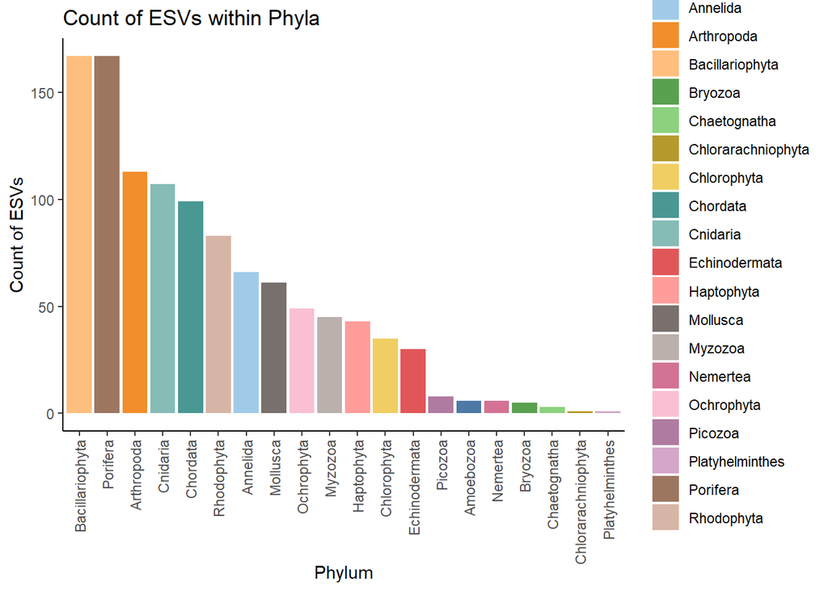

```r
# Summarize the number of unique ESVs per phylum
esv_counts <- Ok2 %>%
  group_by(Phylum) %>%
  summarize(ESV_Count = n_distinct(OTU))

# Create the bar plot
ggplot(esv_counts, aes(x = reorder(Phylum, -ESV_Count), y = ESV_Count, fill = Phylum)) +
  geom_bar(stat = "identity") +
  paletteer:: scale_fill_paletteer_d("ggthemes::Tableau_20") +
  labs(x = "Phylum", y = "Count of ESVs", title = "Count of ESVs within Phyla") +
  theme_classic() +
  theme(axis.text.x = element_text(angle = 90, vjust = 0.5, hjust = 1))
```

## Bar chart unique ESVs by phyla per sample

```r
#Summarizing the number of unique ESVs per sample and phylum
esv_counts_per_sample <- Ok %>%
  otu_table() %>%
  as.data.frame() %>%
  rownames_to_column(var = "OTU") %>%
  gather(key = "Sample", value = "Abundance", -OTU) %>%
  left_join(tax_table(Ok) %>% as.data.frame() %>% rownames_to_column(var = "OTU")) %>%
  filter(Abundance > 0) %>%
  group_by(Sample, Phylum) %>%
  summarize(ESV_Count = n_distinct(OTU), .groups = "drop")
```

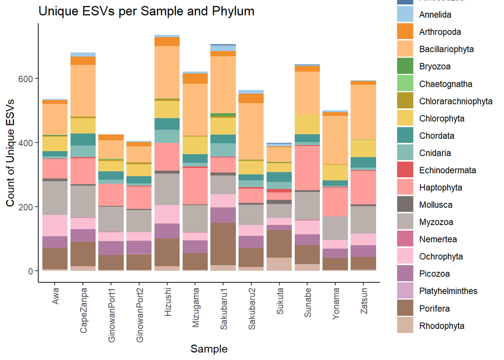

```r
esv_counts_per_sample <- esv_counts_per_sample %>% # add column for sample
  separate(Sample,c("Location", "Depth","Medium","Replicate"), sep = "_", remove = FALSE)

# Bar chart for ESV counts per sample and phylum
ggplot(esv_counts_per_sample, aes(x = Location, y = ESV_Count, fill = Phylum)) +
  geom_bar(stat = "identity", position = "stack") +
  paletteer:: scale_fill_paletteer_d("ggthemes::Tableau_20") +
  labs(x = "Sample", y = "Count of Unique ESVs", fill = "Phylum",
       title = "Unique ESVs per Sample and Phylum") +
  theme_classic() +
  theme(axis.text.x = element_text(angle = 90, vjust = 0.5, hjust = 1))
```

Count unique ESVs per sample and phylum, grouped by impact

```r
#  Count unique ESVs per sample and phylum, grouped by impact
esv_counts_per_sample <- Ok2 %>%
  filter(Abundance > 0) %>%
  group_by(Sample, Location, impact, Phylum) %>%
  summarize(ESV_Count = n_distinct(OTU), .groups = "drop")

# Ensure 'impact' is a factor with levels in the desired order
esv_counts_per_sample$impact <- factor(esv_counts_per_sample$impact, levels = c("low", "medium", "high"))

# Reorder 'Sample' based on 'impact'
esv_counts_per_sample$Location <- reorder(esv_counts_per_sample$Location, as.numeric(esv_counts_per_sample$impact))
```

## Bar chart with samples sorted by impact

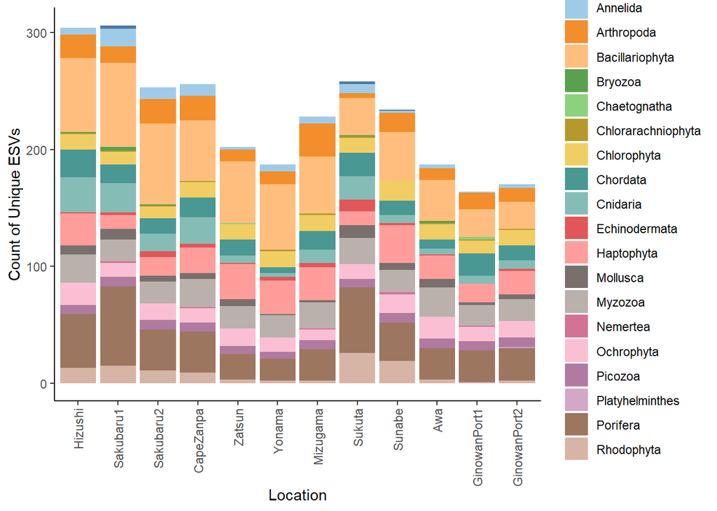

```r
# Count unique ESVs per sample and phylum, grouped by impact
esv_counts_per_site <- Ok2 %>%
  filter(Abundance > 0) %>%
  group_by(Location, impact, Phylum) %>%
  summarize(ESV_Count = n_distinct(OTU), .groups = "drop")

esv_counts_per_site$Location<-ordered(esv_counts_per_site$Location,levels=c("Hizushi", "Sakubaru1", "Sakubaru2", "CapeZanpa", "Zatsun", "Yonama", "Mizugama","Sukuta", "Sunabe", "Awa", "GinowanPort1", "GinowanPort2"))

# Bar chart with samples sorted by impact
unique_ESVs_site_bar <- ggplot(esv_counts_per_site, aes(x = Location, y = ESV_Count, fill = Phylum)) +
  geom_bar(stat = "identity", position = "stack") +
  paletteer:: scale_fill_paletteer_d("ggthemes::Tableau_20") +
  labs(y = "Count of Unique ESVs",fill = "Phylum") +
  theme_classic() +
  theme(axis.text.x = element_text(angle = 90, vjust = 0.5, hjust = 1))

unique_ESVs_site_bar
```

Add faceting by impact

```r
esv_counts_per_site$impact <- ordered(esv_counts_per_site$impact, levels = c( "low", "medium", "high"))
levels(esv_counts_per_site$impact )
```

```
## [1] "low"    "medium" "high"
```

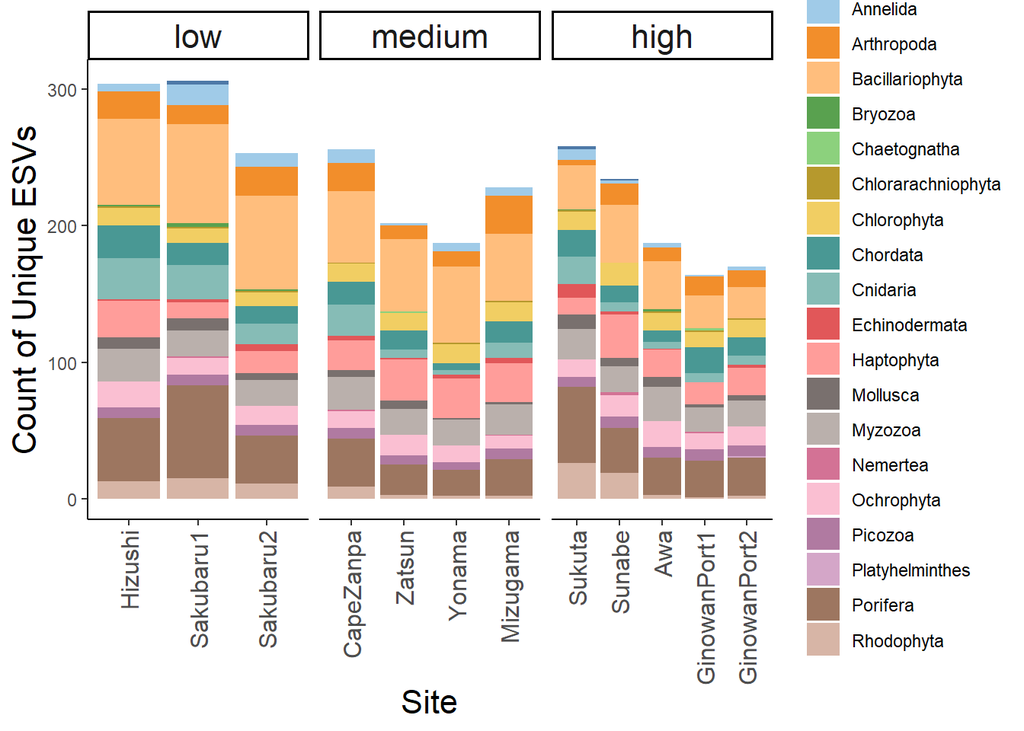

```r
# Bar chart with samples sorted by impact
unique_ESVs_site_bar <- ggplot(esv_counts_per_site, aes(x = Location, y = ESV_Count, fill = Phylum)) +
  geom_bar(stat = "identity", position = "stack") +
  facet_grid( ~ impact, scales = "free")+
  paletteer:: scale_fill_paletteer_d("ggthemes::Tableau_20") +
  labs(y = "Count of Unique ESVs",fill = "Phylum", x= "Site") +
  theme_classic() +
  theme(axis.text.x = element_text(angle = 90, vjust = 0.5, hjust = 1, size = 12),
        strip.text = element_text(
    size = 16),
    axis.title = element_text(size = 16))

unique_ESVs_site_bar
```

Export bar plot of counts of unique ESVs per sampling sit

```r
ggsave("unique_ESVs_site_bar.png",
       plot = unique_ESVs_site_bar,
       units ="in", width = 8, height = 6, dpi = 300,
       path = here::here("Multi-taxa_data","eDNA","4-Visualization_outputs"))
```

# Hierarchical clustering tree based on taxonomic distances

Load the phylogenetic tree (.tre object)

```r
# Read the phylogenetic tree
Ok_tree <- ape::read.tree(file=here("Multi-taxa_data",
                          "eDNA","1-Input_data",
                          "eDNAOkinawaTreenew.tre"))
```

Format data

```r
#want to extract the phylum names for labelling
Ok_tree_df <- as_tibble(Ok_tree)
name_list <- c("Annelida","Arthropoda","Bacillariophyta","Bryozoa","Cercozoa","Chaetognatha","Chlorophyta",
                           "Chordata","Cnidaria","Amoebozoa","Echinodermata","Haptophyta","Mollusca","Nemertea",
   "Picozoa","Platyhelminthes","Porifera","Rhodophyta","Ochrophyta","Dinophyceae")


# Filter the dataframe
filtered_Ok_tree_df <- Ok_tree_df[Ok_tree_df$label %in% name_list, ]
#change manually if necessary
#filtered_Ok_tree_df <- edit(filtered_Ok_tree_df)
```

Plot the phylogenetic tree

```r
#tableau_20_palette <- paletteer::paletteer_d("ggthemes::Tableau_20")

edna_phylo_tree <- ggtree(Ok_tree, branch.length = 'none', layout = "circular") +
  geom_tiplab(size = 5, aes(angle = angle))
```

```
## Trovata più di una classe "phylo" in cache; si utilizza il primo, dal namespace 'phyloseq'
```

```
## Definito anche da 'tidytree'
```

```r
#add labels from your label dataframe

edna_phylo_tree <- edna_phylo_tree +  geom_cladelab(data = filtered_Ok_tree_df, mapping = aes(node = node, label = label),
                      fontsize = 4,
                      angle = 'auto',
                      barsize = 5,
                      offset = 22,
                      extend = 0.3,
                      offset.text = 1,
                      barcolor = c("#FF9D9AFF","#BAB0ACFF","#4E79A7FF","#B07AA1FF","#499894FF","#E15759FF","#F28E2BFF", "#8CD17DFF","#A0CBE8FF", "#59A14FFF","#79706EFF", "#D37295FF", "#D4A6C8FF","#86BCB6FF", "#9D7660FF", "#D7B5A6FF",  "#B6992DFF", "#FABFD2FF", "#FFBE7DFF", "#F1CE63FF" ))
```

```
## ! The "label" has(have) been found in tree data. You might need to rename the
## variable(s) in the data of "geom_cladelab" to avoid this warning!
```

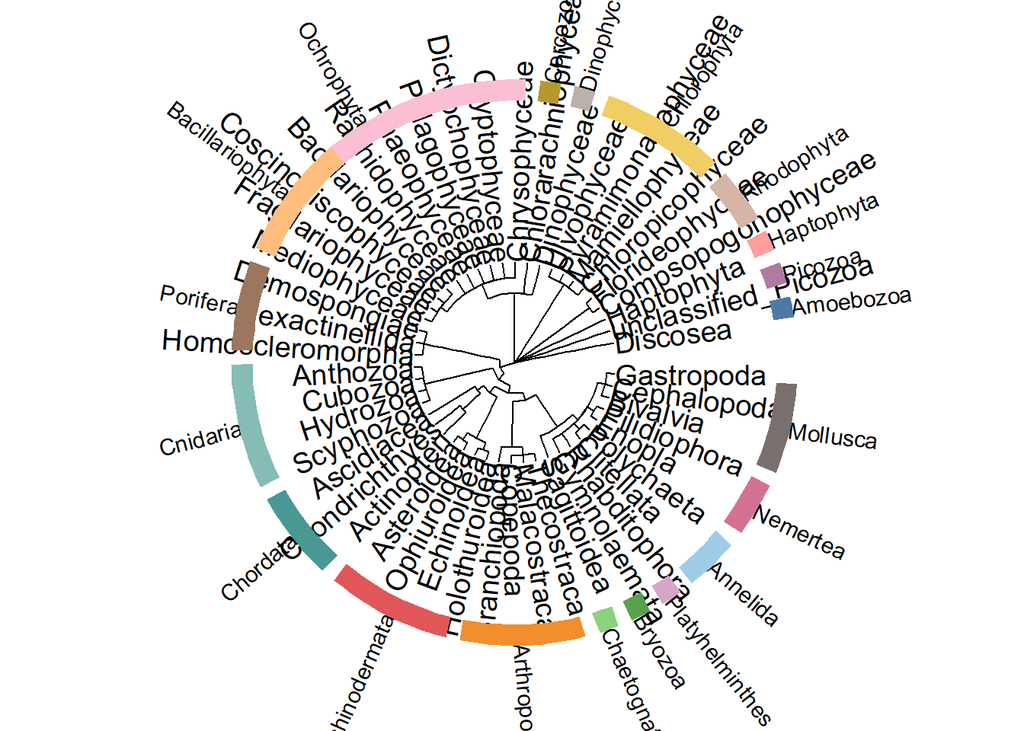

```r
edna_phylo_tree
```

Export phylogenetic tree

```r
ggsave("edna_phylo_tree.png",
       plot = edna_phylo_tree,
       units ="in", width = 9, height = 9, dpi = 600,
       path = here::here("Multi-taxa_data","eDNA","4-Visualization_outputs"))
```

# ALPHA-DIVERSITY

Extract Shannon’s diversity index, observed richness and Pielou’s Evenness

```r
# Shannon's H'
H <- diversity(t(otu_table(Ok)))
# Observed Richness
richness <- specnumber(t(otu_table(Ok)))
# Pielou's Evenness
evenness <- H/log(richness)
```

Create alpha diversity data frame including environmental data

```r
alpha <- cbind(shannon = H, richness = richness, pielou = evenness, Okinawa_env)

head(alpha)
```

```
##                               shannon richness    pielou
## CapeZanpa_shallow_seawater_3 2.925124      118 0.6131456
## CapeZanpa_shallow_seawater_2 2.645393      100 0.5744398
## CapeZanpa_shallow_seawater_1 2.825608      134 0.5769090
## CapeZanpa_deep_seawater_3    2.837101      106 0.6083710
## CapeZanpa_deep_seawater_2    2.775292      100 0.6026470
## CapeZanpa_deep_seawater_1    2.811783      122 0.5852978
##                                                   Samples  Location   depth
## CapeZanpa_shallow_seawater_3 CapeZanpa_shallow_seawater_3 CapeZanpa shallow
## CapeZanpa_shallow_seawater_2 CapeZanpa_shallow_seawater_2 CapeZanpa shallow
## CapeZanpa_shallow_seawater_1 CapeZanpa_shallow_seawater_1 CapeZanpa shallow
## CapeZanpa_deep_seawater_3       CapeZanpa_deep_seawater_3 CapeZanpa    deep
## CapeZanpa_deep_seawater_2       CapeZanpa_deep_seawater_2 CapeZanpa    deep
## CapeZanpa_deep_seawater_1       CapeZanpa_deep_seawater_1 CapeZanpa    deep
##                              impact pop_score freshwater_input fishing_pressure
## CapeZanpa_shallow_seawater_3 medium        -1                0             -0.5
## CapeZanpa_shallow_seawater_2 medium        -1                0             -0.5
## CapeZanpa_shallow_seawater_1 medium        -1                0             -0.5
## CapeZanpa_deep_seawater_3    medium        -1                0             -0.5
## CapeZanpa_deep_seawater_2    medium        -1                0             -0.5
## CapeZanpa_deep_seawater_1    medium        -1                0             -0.5
##                              coast_score human_score herma_score
## CapeZanpa_shallow_seawater_3           0        -0.5        -0.5
## CapeZanpa_shallow_seawater_2           0        -0.5        -0.5
## CapeZanpa_shallow_seawater_1           0        -0.5        -0.5
## CapeZanpa_deep_seawater_3              0        -0.5        -0.5
## CapeZanpa_deep_seawater_2              0        -0.5        -0.5
## CapeZanpa_deep_seawater_1              0        -0.5        -0.5
##                              other_pressures
## CapeZanpa_shallow_seawater_3               0
## CapeZanpa_shallow_seawater_2               0
## CapeZanpa_shallow_seawater_1               0
## CapeZanpa_deep_seawater_3                  0
## CapeZanpa_deep_seawater_2                  0
## CapeZanpa_deep_seawater_1                  0
```

```r
alpha$Location<-ordered(alpha$Location,levels=c("Hizushi", "Sakubaru1", "Sakubaru2", "CapeZanpa", "Zatsun", "Yonama", "Mizugama","Sukuta", "Sunabe", "Awa", "GinowanPort1", "GinowanPort2"))
```

## Box plots of alpha diversity

Boxplot of Shannon’s diversity index based on Location

```r
plot.shan_loc <- ggplot(alpha, aes(x = Location, y = shannon, fill = Location)) +
  geom_boxplot(color = "black", alpha = 0.5) +
  geom_jitter(width = 0.2, height = 0, color = "black", size = 2) +
  scale_fill_manual(values = c("#9F0162","#009F81","#FF5AAF","#00FCCF","#8400CD","#008DF9","#00C2F9","#FFB2FD","#A40122","#E20134","#FF6E3A","#FFC33B")) +
  ylab("Shannon index") +
  xlab("Location") +
  theme_classic() +
  theme(axis.text.x = element_text(angle = 90, hjust = 1, vjust = 0.4))
```

Boxplot of richness based on Location

```r
plot.rich_loc <- ggplot(alpha, aes(x = Location, y = richness, fill = Location)) +
  geom_boxplot(color = "black", alpha = 0.5) +
  geom_jitter(width = 0.2, height = 0, color = "black", size = 2) +
  scale_fill_manual(values = c("#9F0162","#009F81","#FF5AAF","#00FCCF","#8400CD","#008DF9","#00C2F9","#FFB2FD","#A40122","#E20134","#FF6E3A","#FFC33B")) +  #https://mk.bcgsc.ca/colorblind/palettes.mhtml#12-color-palette-for-colorbliness
  ylab("Species Richness") +
  xlab("Location") +
  theme_classic() +
  theme(axis.text.x = element_text(angle = 90, hjust = 1, vjust = 0.4))
```

Boxplot of Pielou’s evenness based on Location

```r
plot.even_loc <- ggplot(alpha, aes(x = Location, y = pielou, fill = Location)) +
  geom_boxplot(color = "black", alpha = 0.5) +
  geom_jitter(width = 0.2, height = 0, color = "black", size = 2) +
  scale_fill_manual(values = c("#9F0162","#009F81","#FF5AAF","#00FCCF","#8400CD","#008DF9","#00C2F9","#FFB2FD","#A40122","#E20134","#FF6E3A","#FFC33B")) +
  ylab("Pielou's Evenness") +
  xlab("Location") +
  theme_classic() +
  theme(axis.text.x = element_text(angle = 90, hjust = 1, vjust = 0.4))
```

Plot grid alpha of diversity boxplots

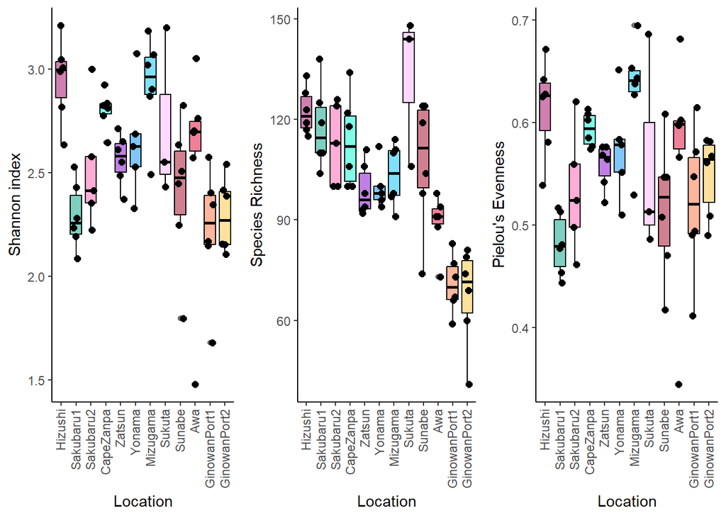

```r
legend <- get_legend(plot.shan_loc)
plot_grid(plot.shan_loc + theme(legend.position = "none"), plot.rich_loc + theme(legend.position = "none"), plot.even_loc + theme(legend.position = "none"), ncol = 3)
```

Export box plot

```r
ggsave("a_diversity_site_box.png",
       units ="in", width = 8, height = 6, dpi = 300,
       path = here::here("Multi-taxa_data","eDNA","4-Visualization_outputs"))
```

## Test differences in alpha diversity by location

```r
kw_richness <- kruskal.test(richness ~ Location, data = alpha)
kw_richness
```

```
##
##  Kruskal-Wallis rank sum test
##
## data:  richness by Location
## Kruskal-Wallis chi-squared = 47.735, df = 11, p-value = 1.592e-06
```

Post-hoc Dunn test for pairwise comparisons

```r
library(dunn.test)

posthoc_richness <- dunn.test(alpha$richness, alpha$Location, method = "bonferroni")
```

```
##   Kruskal-Wallis rank sum test
##
## data: x and group
## Kruskal-Wallis chi-squared = 47.7347, df = 11, p-value = 0
##
##
##                            Comparison of x by group
##                                  (Bonferroni)
## Col Mean-|
## Row Mean |        Awa   CapeZanp   GinowanP   GinowanP    Hizushi   Mizugama
## ---------+------------------------------------------------------------------
## CapeZanp |  -2.498060
##          |     0.4121
## GinowanP |   0.933992   3.432052
##          |     1.0000    0.0198*
## GinowanP |   0.919167   3.417227  -0.014825
##          |     1.0000    0.0209*     1.0000
##  Hizushi |  -3.357926  -0.859866  -4.291919  -4.277094
##          |     0.0259     1.0000    0.0006*    0.0006*
## Mizugama |  -1.452877   1.045182  -2.386870  -2.372045   1.905048
##          |     1.0000     1.0000     0.5608     0.5838     1.0000
## Sakubaru |  -2.846454  -0.348394  -3.780447  -3.765621   0.511472  -1.393576
##          |     0.1459     1.0000    0.0052*    0.0055*     1.0000     1.0000
## Sakubaru |  -2.429867  -0.048060  -3.320394  -3.306258   0.771790  -1.044602
##          |     0.4984     1.0000     0.0297     0.0312     1.0000     1.0000
##   Sukuta |  -2.874888  -0.835230  -3.637490  -3.625385  -0.133152  -1.688618
##          |     0.1334     1.0000    0.0091*    0.0095*     1.0000     1.0000
##   Sunabe |  -2.023651   0.474409  -2.957643  -2.942818   1.334275  -0.570773
##          |     1.0000     1.0000     0.1023     0.1073     1.0000     1.0000
##   Yonama |  -1.089835   1.291971  -1.980362  -1.966227   2.111821   0.295428
##          |     1.0000     1.0000     1.0000     1.0000     1.0000     1.0000
##   Zatsun |  -0.978468   1.519591  -1.912461  -1.897636   2.379457   0.474409
##          |     1.0000     1.0000     1.0000     1.0000     0.5722     1.0000
## Col Mean-|
## Row Mean |   Sakubaru   Sakubaru     Sukuta     Sunabe     Yonama
## ---------+-------------------------------------------------------
## Sakubaru |   0.284120
##          |     1.0000
##   Sukuta |  -0.550768  -0.768859
##          |     1.0000     1.0000
##   Sunabe |   0.822803   0.500391   1.222584
##          |     1.0000     1.0000     1.0000
##   Yonama |   1.624151   1.282982   1.879954   0.839639
##          |     1.0000     1.0000     1.0000     1.0000
##   Zatsun |   1.867985   1.496933   2.075971   1.045182   0.156902
##          |     1.0000     1.0000     1.0000     1.0000     1.0000
##
## alpha = 0.05
## Reject Ho if p <= alpha/2
```

```r
# Convert list to dataframe
posthoc_richness_df <- bind_rows(posthoc_richness)
# Print the dataframe
print(posthoc_richness_df)
```

```
## # A tibble: 66 × 5
##     chi2       Z          P P.adjusted comparisons
##    <dbl>   <dbl>      <dbl>      <dbl> <chr>
##  1  47.7 -2.50   0.00624      0.412    Awa - CapeZanpa
##  2  47.7  0.934  0.175        1        Awa - GinowanPort1
##  3  47.7  3.43   0.000300     0.0198   CapeZanpa - GinowanPort1
##  4  47.7  0.919  0.179        1        Awa - GinowanPort2
##  5  47.7  3.42   0.000316     0.0209   CapeZanpa - GinowanPort2
##  6  47.7 -0.0148 0.494        1        GinowanPort1 - GinowanPort2
##  7  47.7 -3.36   0.000393     0.0259   Awa - Hizushi
##  8  47.7 -0.860  0.195        1        CapeZanpa - Hizushi
##  9  47.7 -4.29   0.00000886   0.000585 GinowanPort1 - Hizushi
## 10  47.7 -4.28   0.00000947   0.000625 GinowanPort2 - Hizushi
## # ℹ 56 more rows
```

```r
# Print results
print(alpha$richness)
```

```
##  [1] 118 100 134 106 100 122 111  92  94  98  93 106 100  98  94 112  96 124 124
## [20] 119 104  98  74 106 144 148 100 113 126 100 124 110 110 119 138 104 125  91
## [39] 110 111  98 114  97 123 128 115 119 117 133  74  79  41  60  69  81  73  83
## [58]  77  66  59  67  73  91  91  88  98  94
```

```r
print(kw_richness)
```

```
##
##  Kruskal-Wallis rank sum test
##
## data:  richness by Location
## Kruskal-Wallis chi-squared = 47.735, df = 11, p-value = 1.592e-06
```

```r
print(posthoc_richness)
```

```
## $chi2
## [1] 47.7347
##
## $Z
##  [1] -2.49806011  0.93399280  3.43205291  0.91916752  3.41722763 -0.01482528
##  [7] -3.35792650 -0.85986639 -4.29191930 -4.27709401 -1.45287769  1.04518242
## [13] -2.38687049 -2.37204521  1.90504881 -2.84645425 -0.34839414 -3.78044705
## [19] -3.76562177  0.51147225 -1.39357656 -2.42986706 -0.04806020 -3.32039425
## [25] -3.30625890  0.77179023 -1.04460253  0.28412058 -2.87488822 -0.83523068
## [31] -3.63749015 -3.62538536 -0.13315272 -1.68861856 -0.55076806 -0.76885922
## [37] -2.02365107  0.47440904 -2.95764387 -2.94281859  1.33427543 -0.57077338
## [43]  0.82280318  0.50039147  1.22258404 -1.08983566  1.29197120 -1.98036285
## [49] -1.96622750  2.11182163  0.29542886  1.62415198  1.28298238  1.87995456
## [55]  0.83963993 -0.97846865  1.51959146 -1.91246145 -1.89763617  2.37945785
## [61]  0.47440904  1.86798560  1.49693381  2.07597192  1.04518242  0.15690241
```

[output cut: 67 more lines]

Extract relevant statistics and export results

```r
# Extracting relevant values
richness_statistic <- kw_richness[["statistic"]]
richness_p_value <- kw_richness[["p.value"]]

# Creating a data frame
df_div_stat <- data.frame(Value = "Richness",
                          ChiSquare = richness_statistic,
                          P_Value = richness_p_value)

df_div_stat
```

```
##                               Value ChiSquare      P_Value
## Kruskal-Wallis chi-squared Richness   47.7347 1.591859e-06
```

Export Stat_test_adiversity_Ok

```r
write.csv(df_div_stat, file = here("Multi-taxa_data",
                                   "eDNA",
                                   "3-Clean_data",
                                   "Stat_test_adiversity_Ok.csv"))
```

## Boxplots of alpha diversity by impact

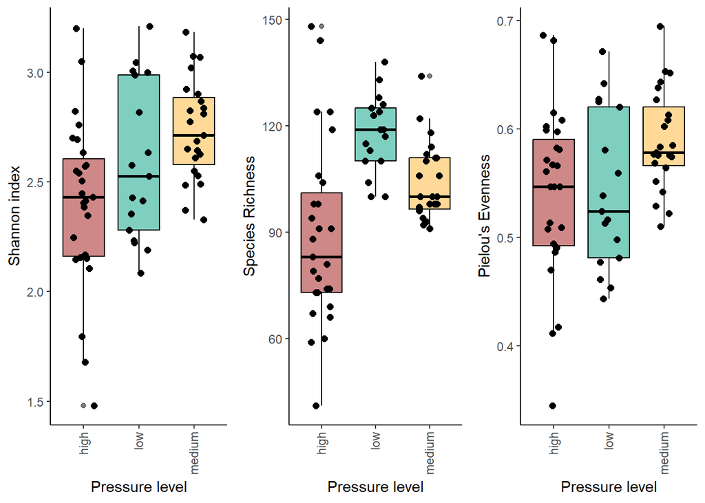

```r
plot.shan_impact <- ggplot(alpha, aes(x = impact, y = shannon, fill = impact)) +
  geom_boxplot(color = "black", alpha = 0.5) +
  geom_jitter(width = 0.2, height = 0, color = "black", size = 2) +
  scale_fill_manual(values = c(medium = "#FFB331",high = "#9F1111", low = "#009F81")) +
  ylab("Shannon index") +
  xlab("Pressure level") +
  theme_classic() +
  theme(axis.text.x = element_text(angle = 90, hjust = 1, vjust = 0.4))

plot.rich_impact <- ggplot(alpha, aes(x = impact, y = richness, fill = impact)) +
  geom_boxplot(color = "black", alpha = 0.5) +
  geom_jitter(width = 0.2, height = 0, color = "black", size = 2) +
  scale_fill_manual(values = c(medium = "#FFB331",high = "#9F1111", low = "#009F81")) +
  ylab("Species Richness") +
  xlab("Pressure level") +
  theme_classic() +
  theme(axis.text.x = element_text(angle = 90, hjust = 1, vjust = 0.4))

plot.even_impact <- ggplot(alpha, aes(x = impact, y = pielou, fill = impact)) +
  geom_boxplot(color = "black", alpha = 0.5) +
  geom_jitter(width = 0.2, height = 0, color = "black", size = 2) +
  scale_fill_manual(values = c(medium = "#FFB331",high = "#9F1111", low = "#009F81")) +
  ylab("Pielou's Evenness") +
  xlab("Pressure level") +
  theme_classic() +
  theme(axis.text.x = element_text(angle = 90, hjust = 1, vjust = 0.4))

# Create a grid of box plots
legend <- get_legend(plot.shan_impact)
plot_grid(plot.shan_impact + theme(legend.position = "none"), plot.rich_impact + theme(legend.position = "none"), plot.even_impact + theme(legend.position = "none"), ncol = 3)
```

```r
ggsave("a_diversity_impact_box.png",
       units ="in", width = 8, height = 6, dpi = 300,
       path = here::here("Multi-taxa_data","eDNA","4-Visualization_outputs"))
```

## Test differences in alpha diversity by impact

```r
kw_richness_impact <- kruskal.test(richness ~ impact, data = alpha)
```

Post-hoc Dunn test for pairwise comparisons among impact level

```r
posthoc_richness_impact <- dunn.test(alpha$richness, alpha$impact, method = "bonferroni")
```

```
##   Kruskal-Wallis rank sum test
##
## data: x and group
## Kruskal-Wallis chi-squared = 22.0034, df = 2, p-value = 0
##
##
##                            Comparison of x by group
##                                  (Bonferroni)
## Col Mean-|
## Row Mean |       high        low
## ---------+----------------------
##      low |  -4.680920
##          |    0.0000*
##   medium |  -2.248967   2.535988
##          |     0.0368    0.0168*
##
## alpha = 0.05
## Reject Ho if p <= alpha/2
```

```r
# Convert list to dataframe
posthoc_richness_impact_df <- bind_rows(posthoc_richness_impact)
# Print the dataframe
print(posthoc_richness_impact_df)
```

```
## # A tibble: 3 × 5
##    chi2     Z          P P.adjusted comparisons
##   <dbl> <dbl>      <dbl>      <dbl> <chr>
## 1  22.0 -4.68 0.00000143 0.00000428 high - low
## 2  22.0 -2.25 0.0123     0.0368     high - medium
## 3  22.0  2.54 0.00561    0.0168     low - medium
```

```r
# Print results
print("Richness")
```

```
## [1] "Richness"
```

```r
print(kw_richness_impact)
```

```
##
##  Kruskal-Wallis rank sum test
##
## data:  richness by impact
## Kruskal-Wallis chi-squared = 22.003, df = 2, p-value = 1.667e-05
```

```r
print(posthoc_richness_impact)
```

```
## $chi2
## [1] 22.00339
##
## $Z
## [1] -4.680921 -2.248967  2.535989
##
## $P
## [1] 1.427947e-06 1.225729e-02 5.606514e-03
##
## $P.adjusted
## [1] 4.283840e-06 3.677186e-02 1.681954e-02
##
## $comparisons
## [1] "high - low"    "high - medium" "low - medium"
```

Extract relevant statistics

```r
# Extracting relevant values
richness_statistic_impact <- kw_richness_impact[["statistic"]]
richness_p_value_impact <- kw_richness_impact[["p.value"]]

# Creating a data frame
df_div_stat_impact <- data.frame(Value = "Richness",
                          ChiSquare = richness_statistic_impact,
                          P_Value = richness_p_value_impact)

df_div_stat_impact
```

```
##                               Value ChiSquare      P_Value
## Kruskal-Wallis chi-squared Richness  22.00339 1.667341e-05
```

Export Stat_test_diversity_Ok_impact

```r
write.csv(df_div_stat, file = here("Multi-taxa_data",
                                   "eDNA",
                                   "3-Clean_data",
                                   "Stat_test_diversity_Ok_impact.csv"))
```

## Testing for differences in the combination of depth and impact

```r
alpha$depth_impact <- interaction(alpha$depth, alpha$impact, sep = "_")
```

Kruskal-Wallis test among depth_impact

```r
# Test for overall differences
kruskal_test <- kruskal.test(richness ~ depth_impact, data = alpha)
print(kruskal_test)
```

```
##
##  Kruskal-Wallis rank sum test
##
## data:  richness by depth_impact
## Kruskal-Wallis chi-squared = 26.261, df = 5, p-value = 7.941e-05
```

Pairwise Dunn test for depth_impact

```r
# Pairwise Dunn test for depth_impact
dunn_result <- dunn.test(alpha$richness, alpha$depth_impact, method = "bonferroni")
```

```
##   Kruskal-Wallis rank sum test
##
## data: x and group
## Kruskal-Wallis chi-squared = 26.261, df = 5, p-value = 0
##
##
##                            Comparison of x by group
##                                  (Bonferroni)
## Col Mean-|
## Row Mean |   deep_hig   deep_low   deep_med   shallow_   shallow_
## ---------+-------------------------------------------------------
## deep_low |  -4.535668
##          |    0.0000*
## deep_med |  -2.463518   2.254893
##          |     0.1032     0.1810
## shallow_ |  -1.966920   2.936784   0.629856
##          |     0.3689    0.0249*     1.0000
## shallow_ |  -3.788038   0.557810  -1.584600  -2.209263
##          |    0.0011*     1.0000     0.8479     0.2037
## shallow_ |  -2.688053   1.953393  -0.278685  -0.907582   1.306197
##          |     0.0539     0.3808     1.0000     1.0000     1.0000
##
## alpha = 0.05
## Reject Ho if p <= alpha/2
```

```r
dunn_result_df <- bind_rows(dunn_result)
# Print the dataframe
print(dunn_result_df)
```

```
## # A tibble: 15 × 5
##     chi2      Z          P P.adjusted comparisons
##    <dbl>  <dbl>      <dbl>      <dbl> <chr>
##  1  26.3 -4.54  0.00000287  0.0000431 deep_high - deep_low
##  2  26.3 -2.46  0.00688     0.103     deep_high - deep_medium
##  3  26.3  2.25  0.0121      0.181     deep_low - deep_medium
##  4  26.3 -1.97  0.0246      0.369     deep_high - shallow_high
##  5  26.3  2.94  0.00166     0.0249    deep_low - shallow_high
##  6  26.3  0.630 0.264       1         deep_medium - shallow_high
##  7  26.3 -3.79  0.0000759   0.00114   deep_high - shallow_low
##  8  26.3  0.558 0.288       1         deep_low - shallow_low
##  9  26.3 -1.58  0.0565      0.848     deep_medium - shallow_low
## 10  26.3 -2.21  0.0136      0.204     shallow_high - shallow_low
## 11  26.3 -2.69  0.00359     0.0539    deep_high - shallow_medium
## 12  26.3  1.95  0.0254      0.381     deep_low - shallow_medium
## 13  26.3 -0.279 0.390       1         deep_medium - shallow_medium
## 14  26.3 -0.908 0.182       1         shallow_high - shallow_medium
## 15  26.3  1.31  0.0957      1         shallow_low - shallow_medium
```

## Violin plots of alpha diversity

Violin plots of alpha diversity by impact

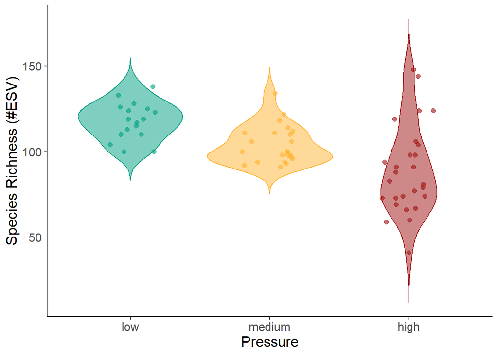

```r
alpha$impact <- factor(alpha$impact, levels = c("low", "medium", "high"))

violin_rich_pressure <- ggplot(alpha, aes(x = impact, y = richness,
                                   fill = impact,
                                   color = impact)) +
  geom_violin(alpha = 0.5, trim = F, draw_quantiles = T) +
  geom_jitter(width = 0.2, height = 0, size = 2,  alpha = 0.6) +
  ylab("Species Richness (#ESV)") +
  scale_fill_manual(values = c(medium = "#FFB331",high = "#9F1111", low = "#009F81"))+
  scale_color_manual(values= c(medium = "#FFB331",high = "#9F1111", low = "#009F81"))+
  xlab("Pressure")+
  theme_classic()+
  theme(axis.text = element_text(size = 12),
        axis.title = element_text(size = 15))+
  guides(fill = "none",
         color = "none")

violin_rich_pressure
```

Export violin_rich_pressure violin plot

```r
ggsave("violin_rich_pressure.png",
       plot = violin_rich_pressure,
       units ="in", width = 8, height = 5, dpi = 300,
       path = here::here("Multi-taxa_data","eDNA","4-Visualization_outputs"))
```

Violin plots of alpha diversity by depth

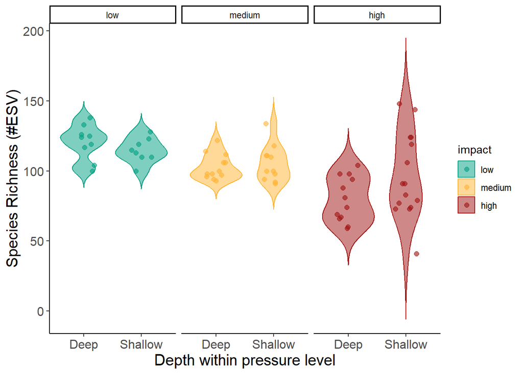

```r
violin_rich_pressure_depth <- ggplot(alpha, aes(x = depth, y = richness,
                                         fill = impact,
                                         color = impact)) +
  geom_violin(alpha = 0.5, trim = F, draw_quantiles = F) +
  geom_jitter(width = 0.2, height = 0, size = 2, alpha = 0.6) +
  facet_grid(~ impact)+
  ylab("Species Richness (#ESV)") +
  xlab("Depth within pressure level") +
  scale_x_discrete(label = c("Deep", "Shallow"))+
  scale_fill_manual(values = c(medium = "#FFB331",high = "#9F1111", low = "#009F81")) +
  scale_color_manual(values = c(medium = "#FFB331",high = "#9F1111", low = "#009F81")) +
  scale_alpha_manual(values=c(1,.6))+
  theme_classic()+
  theme(axis.text = element_text(size = 12),
        axis.title = element_text(size = 15))

violin_rich_pressure_depth
```

Export violin_rich_pressure_depth violin plot

```r
ggsave("violin_rich_pressure.png",
       plot = violin_rich_pressure_depth,
       units ="in", width = 8, height = 6, dpi = 600,
       path = here::here("Multi-taxa_data","eDNA","4-Visualization_outputs"))
```

# Beta diversity

Jaccard’s Index (presence/absence)

```r
Ok.j <- t(otu_table(Ok))
Ok.jac <- vegdist(Ok.j, method = "jaccard", binary = T)
```

## Dendrogram

[figure not shown]

```r
dendro <- hclust(d = Ok.jac, method = "complete")
plot(dendro, hang = -1, main = "Dendrogram",
     ylab = "Similarity",
     xlab="", sub="")
```

```r
cofresult <- cophenetic(dendro)
cor(cofresult, Ok.jac)
```

```
## [1] 0.8630681
```

## NMDS

```r
set.seed(69)
Ok_nmds = metaMDS(t(otu_table(Ok)),
                  distance = "jac",
                  k = 3,
                  maxit = 999,
                  trymax = 20,
                  wascores = TRUE,
                  tidy = TRUE)
```

```
## Square root transformation
## Wisconsin double standardization
## *** Best solution repeated 6 times
```

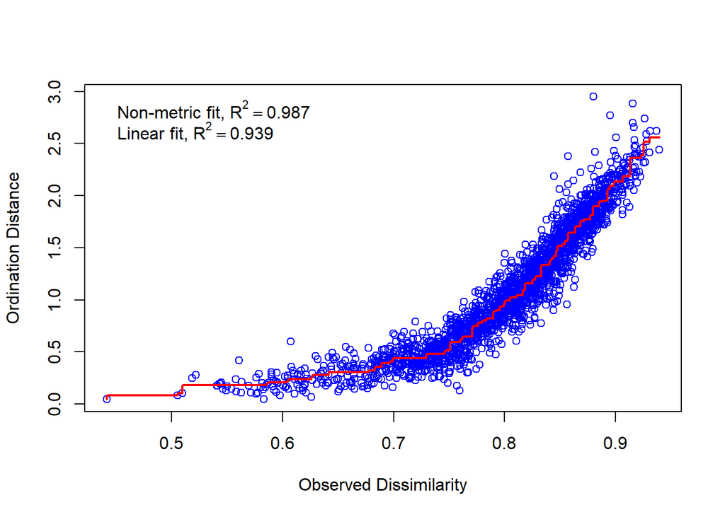

```r
stressplot(Ok_nmds)
```

Format data fot NMDs with ggplot2

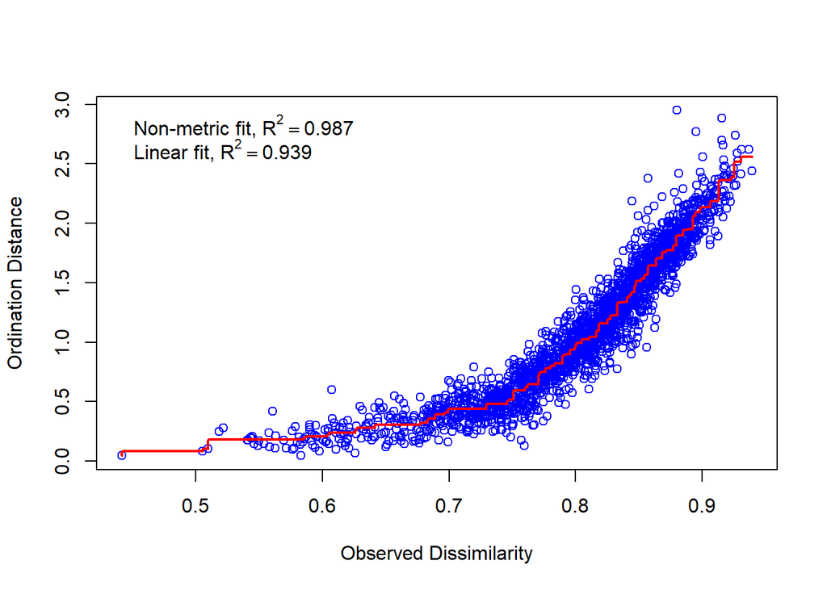

```r
#extract NMDS scores (x and y coordinates)
Ok_data.scores = as.data.frame(scores(Ok_nmds$points))

#add columns to data frame
Ok_data.scores$depth = Okinawa_env$depth
Ok_data.scores$Location = Okinawa_env$Location
Ok_data.scores$impact = Okinawa_env$impact

stressplot(Ok_nmds)
```

```r
Ok_data.scores <- Ok_data.scores %>%
  mutate(Site = case_when(Location == 'Hizushi' ~ "HI",
                          Location == 'Sakubaru1' ~ "S1",
                          Location == 'Sakubaru2' ~ "S2",
                          Location == 'CapeZanpa' ~ "ZP",
                          Location == 'Zatsun' ~ "ZA",
                          Location == 'Yonama' ~ "YO",
                          Location == 'Sunabe' ~ "SN",
                          Location == 'Mizugama' ~ "MI",
                          Location == 'GinowanPort1' ~ "G1",
                          Location == 'GinowanPort2' ~ "G2",
                          Location == 'Sukuta' ~ "SK",
                          Location == 'Awa' ~ "AW")
  )

Ok_data.scores <- Ok_data.scores %>%
  mutate(Pressure = as.factor(case_when(impact == 'low' ~ "Low",
                              impact == 'medium' ~ "Medium",
                              impact == 'high' ~ "High"))
  )

Ok_data.scores$Pressure <- factor(Ok_data.scores$Pressure,
                                 levels = c("Low","Medium","High"))

Ok_data.scores$Site<-ordered(Ok_data.scores$Site,
                     levels=c("HI", "S1", "S2", "ZP", "ZA", "YO", "MI","SK", "SN", "AW", "G1", "G2"))

Ok_data.scores <- Ok_data.scores %>% rename(Depth = depth)
```

NMDS plot

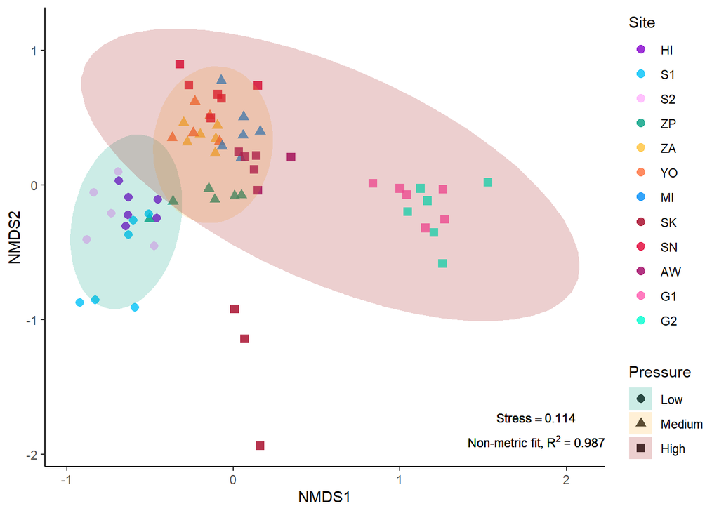

```r
plot.nmds = ggplot(Ok_data.scores, aes(x = MDS1, y = MDS2)) +
  geom_point(size = 2.5, aes(shape = Pressure, colour = Site), alpha = 0.8) +
  stat_ellipse(geom = "polygon", aes(fill = Pressure), alpha = 0.2) +
  scale_color_manual(values = c("#8400CD","#00C2F9","#FFB2FD","#009F81","#FFC33B","#FF6E3A","#008DF9","#A40122","#E20134","#9F0162","#FF5AAF","#00FCCF")) +
  scale_fill_manual(values = c(Low = "#009F81",Medium = "#FFB331",High = "#9F1111")) +
  annotate("text", x=Inf, y=-Inf, hjust = 1, vjust = -0.5,
           label=bquote(atop(Stress == .(round(Ok_nmds$stress,3)),
                             'Non-metric fit,'~ R^2~"= 0.987")),
           size=3)+
  labs(x = "NMDS1", colour = "Site", y = "NMDS2") +
  guides(color= guide_legend(order=1, title = "Site", ncol =1))+
  theme_classic()

plot.nmds
```

Export nMDS

```r
ggsave("edna_nmds.tiff",
       units ="in", width = 8, height = 6, dpi = 300, compression = 'lzw',
       path = here::here("Multi-taxa_data","eDNA","4-Visualization_outputs"))

ggsave("edna_nmds.png",
       units ="in", width = 8, height = 6, dpi = 300,
       path = here::here("Multi-taxa_data","eDNA","4-Visualization_outputs"))
```

## Format and export data for Primer

```r
edna_primer <- otu_table(Ok)

edna_primer <- data.frame(otu_table(Ok))
edna_primer$ESV <- rownames(otu_table(Ok))
edna_primer <- edna_primer[,c(68,1:67)]

Okinawa_env_primer <- Okinawa_env[,c(2:4)] %>%
  mutate(Location_depth = paste(Location, depth, sep='_')) %>%
  mutate(Impact_depth = paste(impact, depth, sep='_'))

Okinawa_env_primer <- t(Okinawa_env_primer)
```

### Export each data frame to separate sheets in same Excel file

```r
openxlsx::write.xlsx(list("edna_mat_primer" = edna_primer,
                            "ind_df_primer" = Okinawa_env_primer),
                       file = here("Multi-taxa_data",
                                   "eDNA",
                                   "3-Clean_data",
                                   "edna_primer.xlsx")
                     )
```

## PERMDISP

PERMDISP BY LOCATION

```r
betad.Ok <- betadisper(Ok.jac, Okinawa_env$Location)
permutest(betad.Ok)
```

```
##
## Permutation test for homogeneity of multivariate dispersions
## Permutation: free
## Number of permutations: 999
##
## Response: Distances
##           Df   Sum Sq   Mean Sq     F N.Perm Pr(>F)
## Groups    11 0.078829 0.0071662 5.668    999  0.001 ***
## Residuals 55 0.069539 0.0012643
## ---
## Signif. codes:  0 '***' 0.001 '**' 0.01 '*' 0.05 '.' 0.1 ' ' 1
```

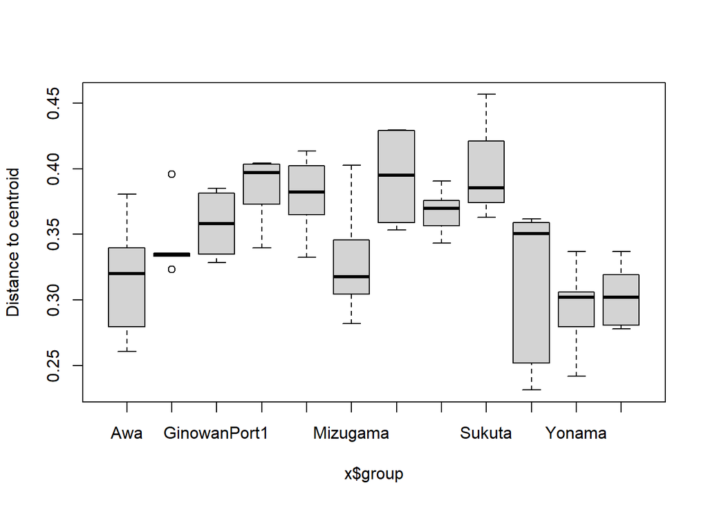

```r
boxplot(betad.Ok)
```

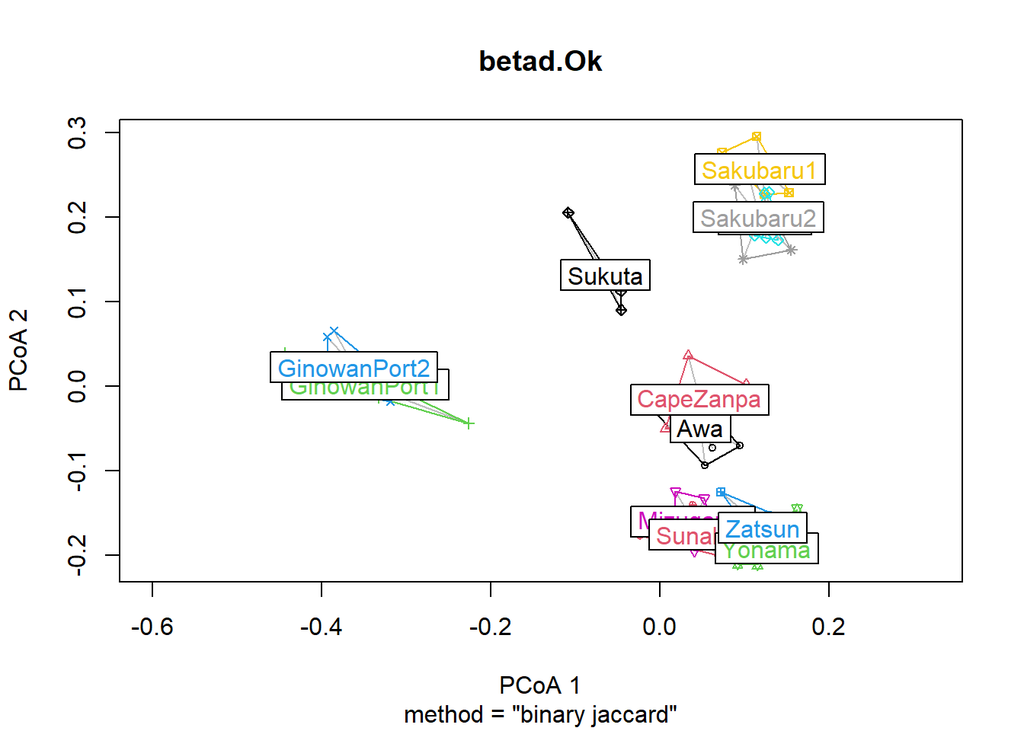

```r
plot(betad.Ok)
```

PERMDISP BY IMPACT

```r
betad.Ok.i <- betadisper(Ok.jac, Okinawa_env$impact)
permutest(betad.Ok.i)
```

```
##
## Permutation test for homogeneity of multivariate dispersions
## Permutation: free
## Number of permutations: 999
##
## Response: Distances
##           Df   Sum Sq  Mean Sq      F N.Perm Pr(>F)
## Groups     2 0.089329 0.044665 17.419    999  0.001 ***
## Residuals 64 0.164104 0.002564
## ---
## Signif. codes:  0 '***' 0.001 '**' 0.01 '*' 0.05 '.' 0.1 ' ' 1
```

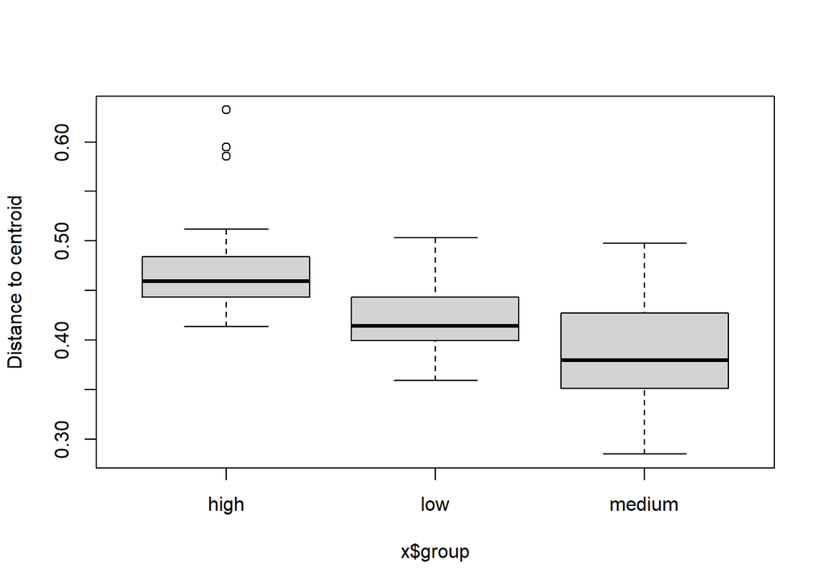

```r
boxplot(betad.Ok.i)
```

## Boxplot of within-site distance from centroid visualization with `ggplot()`

```r
#Create an input dataframe for the boxplot with mean relative cover by
#category and depth within site

betad.Ok$distances #Extract betadisper scores
```

```
##    CapeZanpa_shallow_seawater_3    CapeZanpa_shallow_seawater_2
##                       0.3339536                       0.3356719
##    CapeZanpa_shallow_seawater_1       CapeZanpa_deep_seawater_3
##                       0.3352884                       0.3232281
##       CapeZanpa_deep_seawater_2       CapeZanpa_deep_seawater_1
##                       0.3335097                       0.3957489
##       Zatsun_shallow_seawater_3       Zatsun_shallow_seawater_2
##                       0.2996261                       0.2809565
##       Zatsun_shallow_seawater_1          Zatsun_deep_seawater_3
##                       0.3194789                       0.3371355
##          Zatsun_deep_seawater_2          Zatsun_deep_seawater_1
##                       0.2780494                       0.3045363
##       Yonama_shallow_seawater_3       Yonama_shallow_seawater_2
##                       0.3019433                       0.2796003
##          Yonama_deep_seawater_1          Yonama_deep_seawater_3
##                       0.2420520                       0.3370540
##          Yonama_deep_seawater_2       Sunabe_shallow_seawater_3
##                       0.3059601                       0.3617701
##       Sunabe_shallow_seawater_2       Sunabe_shallow_seawater_1
##                       0.3449942                       0.3588865
##          Sunabe_deep_seawater_3          Sunabe_deep_seawater_2
##                       0.2520162                       0.2315188
##          Sunabe_deep_seawater_1       Sukuta_shallow_seawater_3
##                       0.3560773                       0.4566131
##       Sukuta_shallow_seawater_2       Sukuta_shallow_seawater_1
##                       0.3629922                       0.3853128
##    Sakubaru2_shallow_seawater_3    Sakubaru2_shallow_seawater_1
##                       0.3906788                       0.3697653
##       Sakubaru2_deep_seawater_3       Sakubaru2_deep_seawater_2
##                       0.3565270                       0.3759077
##       Sakubaru2_deep_seawater_1    Sakubaru1_shallow_seawater_3
##                       0.3432382                       0.3690142
##    Sakubaru1_shallow_seawater_2    Sakubaru1_shallow_seawater_1
##                       0.3591411                       0.3533096
##       Sakubaru1_deep_seawater_3       Sakubaru1_deep_seawater_2
##                       0.4290296                       0.4214253
##       Sakubaru1_deep_seawater_1     Mizugama_shallow_seawater_3
##                       0.4293816                       0.3134984
##     Mizugama_shallow_seawater_2     Mizugama_shallow_seawater_1
##                       0.4028051                       0.3216981
```

[output cut: 13 more lines]

```
##                       0.4034457                       0.4043678
##    GinowanPort2_deep_seawater_1 GinowanPort1_shallow_seawater_3
##                       0.3979620                       0.3538588
## GinowanPort1_shallow_seawater_2 GinowanPort1_shallow_seawater_1
##                       0.3814855                       0.3849894
##    GinowanPort1_deep_seawater_3    GinowanPort1_deep_seawater_2
##                       0.3350837                       0.3621955
##    GinowanPort1_deep_seawater_1          Awa_shallow_seawater_3
##                       0.3283861                       0.3805760
##          Awa_shallow_seawater_2          Awa_shallow_seawater_1
##                       0.3296911                       0.2797712
##             Awa_deep_seawater_3             Awa_deep_seawater_2
##                       0.2607002                       0.3105449
##             Awa_deep_seawater_1
##                       0.3399590
```

```r
distcent_df <- data.frame(Distance_to_centroid=betad.Ok$distances,
                          Location=Okinawa_env$Location,
                          Pressure=Okinawa_env$impact)
Location <- betad.Ok$group
distcent_df[,2]<-factor(distcent_df[,2],
                        levels=c("Hizushi", "Sakubaru1", "Sakubaru2", "CapeZanpa", "Zatsun", "Yonama", "Mizugama","Sukuta", "Sunabe", "Awa", "GinowanPort1", "GinowanPort2"))
distcent_df[,3]<-factor(distcent_df[,3],levels=c("low","medium","high"))

distcent_mean_df <- distcent_df %>%
  group_by(Location) %>%
  summarise(`Mean distance to centroid`=round(mean(Distance_to_centroid),2),
            SD=round(mean(Distance_to_centroid),2)) %>%
  mutate(Pressure = case_when(Location == 'Hizushi' |
                                Location == "Sakubaru1" |
                                Location == "Sakubaru2" ~ "Low",
                              Location == "CapeZanpa" |
                                Location == 'Zatsun' |
                                Location == "Yonama" |
                                Location == "Mizugama" ~ "Medium",
                              Location == 'Sukuta' |
                                Location == 'Sunabe' |
                                Location == "Awa" |
                                Location == "GinowanPort1" |
                                Location == "GinowanPort2"~ "High"))

distcent_mean_df <- distcent_mean_df[,c(1,4,2,3)]
distcent_mean_df$Location <- c("HI", "S1", "S2", "ZP", "ZA", "YO", "MI","SK", "SN", "AW", "G1", "G2")

distcent_df <- distcent_df %>%
  mutate(Location = case_when(Location == "Hizushi" ~ "HI",
                              Location == "Sakubaru1" ~ "S1",
                              Location == "Sakubaru2" ~ "S2",
                              Location == "CapeZanpa" ~ "ZP",
                              Location == "Zatsun" ~ "ZA",
                              Location == "Yonama" ~ "YO",
                              Location == "Mizugama" ~ "MI",
                              Location == "Sukuta" ~ "SK",
                              Location == "Sunabe" ~ "SN",
                              Location == "Awa" ~ "AW",
                              Location == "GinowanPort1" ~ "G1",
                              Location == "GinowanPort2" ~ "G2"
  )
  )

distcent_df$Location<-ordered(distcent_df$Location,
                                   levels=c("HI", "S1", "S2", "ZP", "ZA", "YO", "MI","SK", "SN", "AW", "G1", "G2"))
```

Distance to centroid boxplot by location

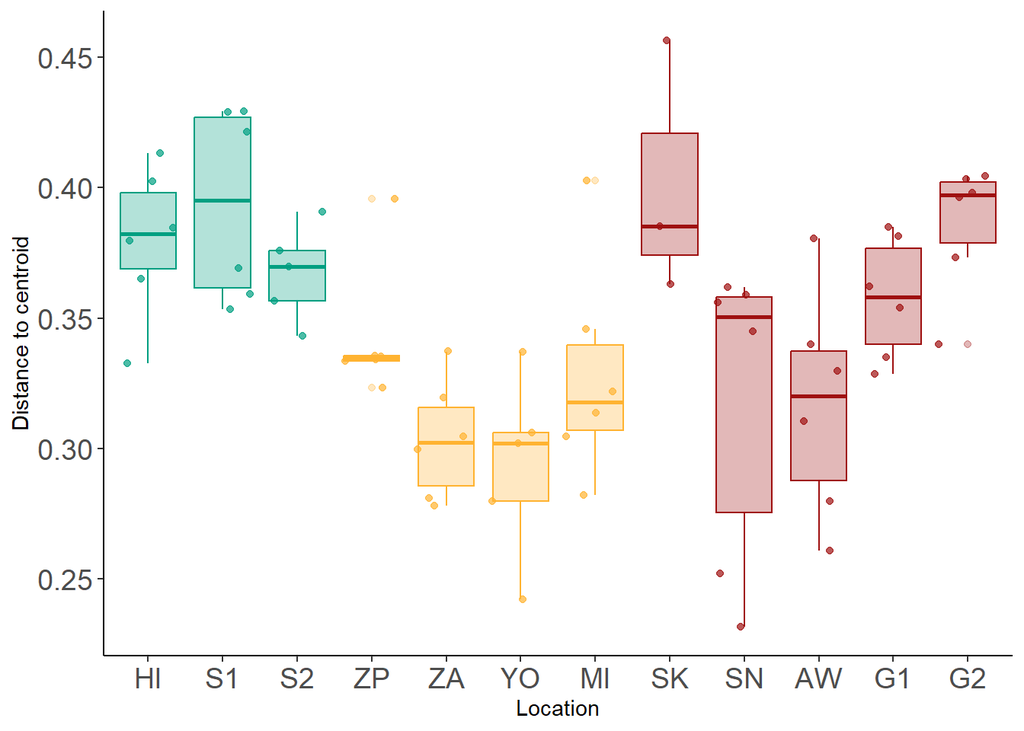

```r
edna_location_box <- ggplot(data=distcent_df,aes(x=Location,y=Distance_to_centroid))+
  geom_boxplot(aes(fill=Pressure,colour=Pressure),alpha=0.3)+
  geom_jitter(aes(fill=Pressure,color=Pressure),alpha=0.7)+
  scale_fill_manual(values= c("#009F81", "#FFB331","#9F1111"))+
  scale_color_manual(values= c("#009F81", "#FFB331","#9F1111"))+
  theme_classic()+
  ylab(label="Distance to centroid")+
  theme(legend.position = "none", #remove legend
        plot.title  = element_text(hjust = 0.5, face= "bold", size =14),
        axis.text=element_text(size=14))

edna_location_box
```

Add table with distance to centroid to the boxplot

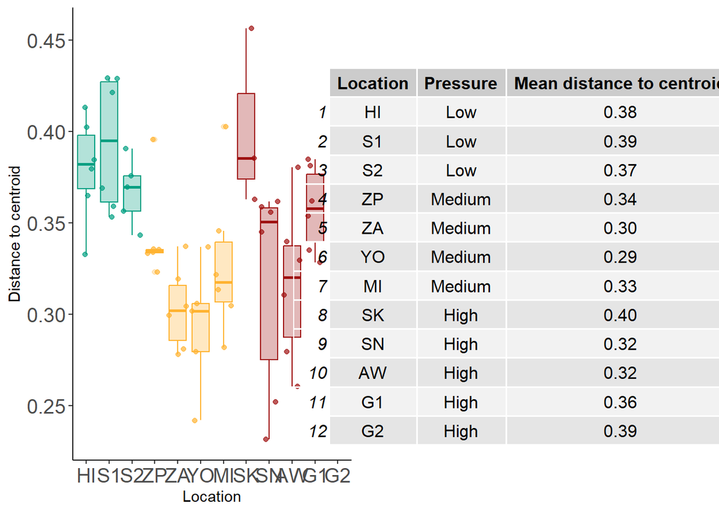

```r
ggpubr:: ggarrange(edna_location_box,
                   gridExtra::tableGrob(distcent_mean_df),
                   ncol = 2, widths = c(1,1))
```

Export eDNA_site_box

```r
ggsave("eDNA_site_box.tiff",
       units="in", width=12, height=4, dpi=300, compression = 'lzw',
       path = here ("Multi-taxa_data","eDNA","4-Visualization_outputs"))

ggsave("eDNA_site_box.png",
       units="in", width=12, height=4, dpi=300,
       path = here ("Multi-taxa_data","eDNA","4-Visualization_outputs"))
```

# dbRDA (Distance-based redundancy analysis)

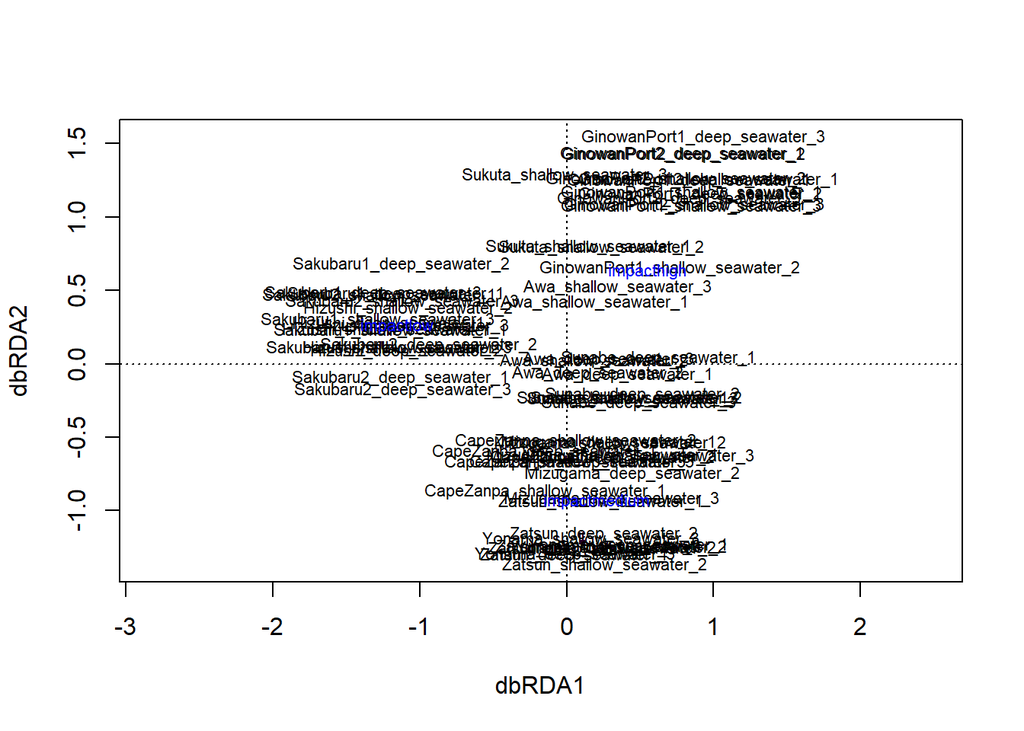

```r
Ok_rda <- dbrda(Ok.jac ~ impact, data = Okinawa_env)
plot(Ok_rda)
```

```r
db.res.axis <- anova.cca(Ok_rda, by = "axis")
db.res.axis
```

```
## Permutation test for dbrda under reduced model
## Forward tests for axes
## Permutation: free
## Number of permutations: 999
##
## Model: dbrda(formula = Ok.jac ~ impact, data = Okinawa_env)
##          Df SumOfSqs      F Pr(>F)
## dbRDA1    1   1.5641 7.8360  0.001 ***
## dbRDA2    1   1.0646 5.3336  0.001 ***
## Residual 64  12.7747
## ---
## Signif. codes:  0 '***' 0.001 '**' 0.01 '*' 0.05 '.' 0.1 ' ' 1
```

```r
db.res.var <- anova.cca(Ok_rda, by = "term")
db.res.var
```

```
## Permutation test for dbrda under reduced model
## Terms added sequentially (first to last)
## Permutation: free
## Number of permutations: 999
##
## Model: dbrda(formula = Ok.jac ~ impact, data = Okinawa_env)
##          Df SumOfSqs      F Pr(>F)
## impact    2   2.6287 6.5848  0.001 ***
## Residual 64  12.7747
## ---
## Signif. codes:  0 '***' 0.001 '**' 0.01 '*' 0.05 '.' 0.1 ' ' 1
```

```r
db_r_quadr <- RsquareAdj(Ok_rda)
db_r_quadr
```

```
## $r.squared
## [1] 0.1706577
##
## $adj.r.squared
## [1] 0.1447407
```

```r
anova(Ok_rda, by = "term")
```

```
## Permutation test for dbrda under reduced model
## Terms added sequentially (first to last)
## Permutation: free
## Number of permutations: 999
##
## Model: dbrda(formula = Ok.jac ~ impact, data = Okinawa_env)
##          Df SumOfSqs      F Pr(>F)
## impact    2   2.6287 6.5848  0.001 ***
## Residual 64  12.7747
## ---
## Signif. codes:  0 '***' 0.001 '**' 0.01 '*' 0.05 '.' 0.1 ' ' 1
```

```r
plot_Ok_rda <- Ok_rda %>%
  scores(tidy = TRUE) %>%
  split(.[["score"]])

plot_Ok_rda$centroids
```

```
##                    dbRDA1     dbRDA2     score        label
## impacthigh      0.5534544  0.6314346 centroids   impacthigh
## impactlow.1    -1.1545388  0.2582929 centroids    impactlow
## impactmedium.1  0.2036474 -0.9321615 centroids impactmedium
```

```r
Ok_rda_scores <- as.data.frame(scores(plot_Ok_rda, display = "site"))
```

Combine scores with original data

```r
Ok_plot_data <- cbind(Okinawa_env, Ok_rda_scores)

Ok_plot_data <- Ok_plot_data %>% rename(Pressure = impact,
                                        Site = Location)
Ok_plot_data$Pressure <- factor(Ok_plot_data$Pressure,
                                  levels = c("low","medium","high"))
```

Add the environmental variables as arrows

```r
arrowmat <- as.data.frame(plot_Ok_rda$centroids)
arrowmat$label <- c("High pressure","Low pressure", "Medium pressure")
```

Plot and dbRDA

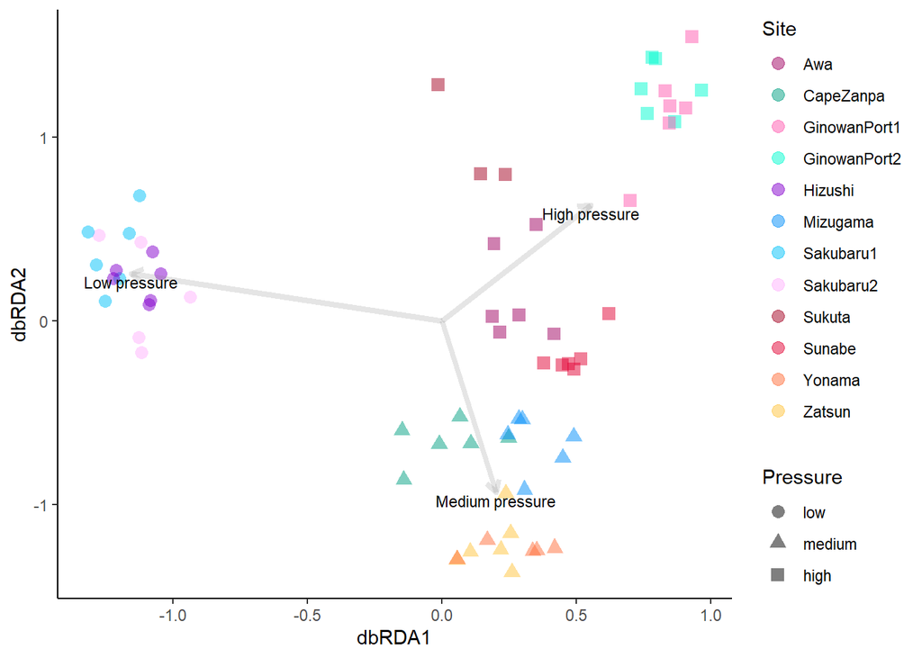

```r
plot_rda <- ggplot(Ok_plot_data) +
  geom_point(size = 3, aes(x = dbRDA1, y = dbRDA2, color = Site, shape = Pressure), alpha = 0.5) +
  #geom_text_repel(aes(label = Samples, color = Location),size = 3, box.padding = 0.5) +  # Add text labels without overlap
  labs(x = "dbRDA1",y = "dbRDA2", shape = "Pressure",color = "Site") +
  theme_classic() +
  scale_color_manual(values = c("#9F0162","#009F81","#FF5AAF","#00FCCF","#8400CD","#008DF9","#00C2F9","#FFB2FD","#A40122","#E20134","#FF6E3A","#FFC33B"))


# Plot arrows and labels
edna_rda <- plot_rda +  geom_segment(data = arrowmat, aes(x = 0, y = 0, xend = dbRDA1, yend = dbRDA2),
                         arrow = arrow(length = unit(0.1, "inches")), color = "gray50", size = 1.5, alpha = 0.2) +
    geom_text(data = arrowmat, aes(label = label, x = dbRDA1, y = dbRDA2),
            size = 3, vjust = 1.2, hjust = 0.5, color = "black") +
  labs(x = "dbRDA1",
       y = "dbRDA2") +
  theme_classic()
edna_rda
```

Export eDNA_rda

```r
ggsave("eDNA_rda.png",
       plot = edna_rda,
       units="in", width=10, height=6, dpi=300,
       path = here ("Multi-taxa_data","eDNA","4-Visualization_outputs"))
```

# TAXONOMIC RICHNESS PIE CHARTS

Create pie charts based on taxonomic richness on the family level merge based on Location

```r
Ok_merge <- merge_samples(Ok, "Location")
Ok_merge_fam <- tax_glom(Ok_merge, "Family")
otu_table(Ok_merge_fam) <- ifelse(otu_table(Ok_merge_fam) > 0 ,1,0)
Ok_merge_fam_melt <- psmelt(Ok_merge_fam)
colours <- viridis(20)


family_counts_total <- Ok_merge_fam_melt %>%
  group_by(Sample, Phylum) %>%
  summarize(TotalFamilies = sum(Abundance > 0)) %>%
  ungroup()
```

Calculate the number of taxonomic families assigned at each site

```r
family_counts_phylum <- family_counts_total %>%
  group_by(Phylum) %>%
  summarize(TotalFamilies = sum(TotalFamilies)) %>%
  ungroup()
```

## Pie chart with colored borders around Phylum groups of the whole data set

```r
pie_chart_total <- ggplot(family_counts_phylum,
                          aes(x = "", y = TotalFamilies, fill = Phylum)) +
  geom_bar(stat = "identity", colour = "black", size = 1) +  # Borders for Phylum
  coord_polar("y", start = 0) +
  ggtitle("Total Dataset by Phylum") +
  paletteer:: scale_fill_paletteer_d("ggthemes::Tableau_20")+  # Specify the color palette
  theme_void()
  theme_void()
```

[output not shown]

[output cut: 94 more lines]

[output not shown]

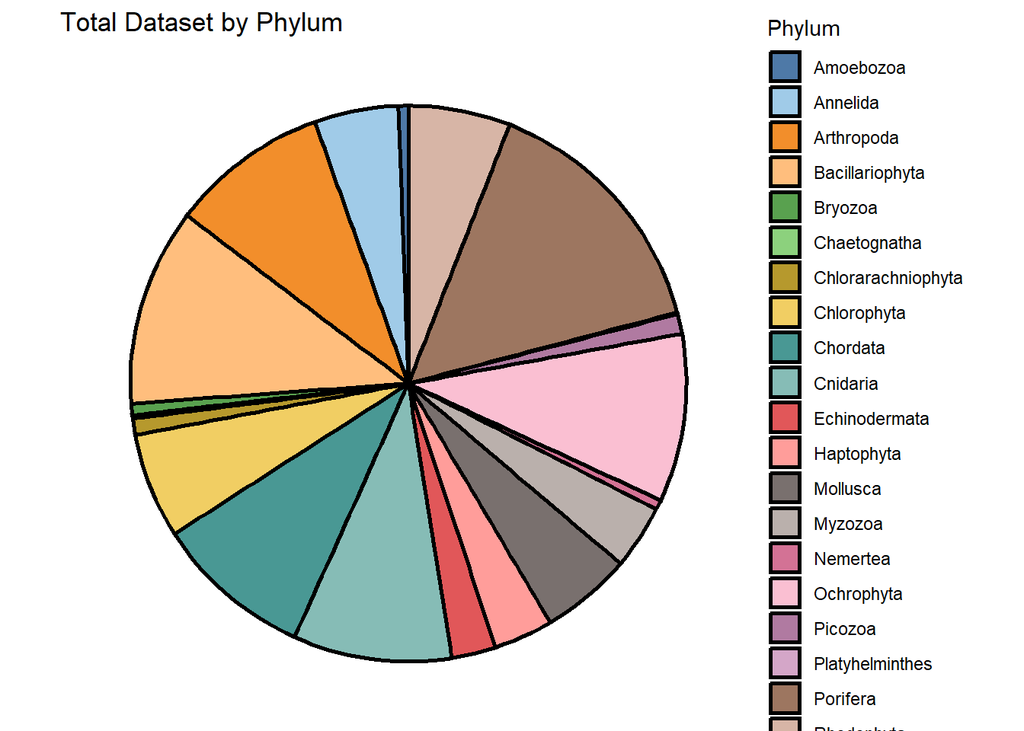

```r
pie_chart_total
```

## Pie charts based on taxonomic richness on the family level for each location

Calculate total families for each location

```r
total_families <- Ok_merge_fam_melt %>%
  group_by(Sample, Phylum) %>%
  summarise(TotalFamilies = sum(Abundance > 0)) %>%
  ungroup() %>%
  group_by(Sample) %>%
  summarise(TotalFamilies = sum(TotalFamilies))
```

Filter phyla based on threshold for each location

```r
#Determine the threshold for each location
total_families <- total_families %>%
  mutate(Threshold = 0.1 * TotalFamilies)

#Filter phyla based on threshold for each location
family_counts <- Ok_merge_fam_melt %>%
  group_by(Sample, Phylum) %>%
  summarise(TotalFamilies = sum(Abundance > 0)) %>%
  ungroup() %>%
  left_join(total_families, by = "Sample")
```

Pie charts for each location with black borders (loop using the `map` function from `purrr` package)

```r
pie_charts <- family_counts %>%
  group_split(Sample) %>%
  map(~ {
    site_data <- .
    ggplot(site_data, aes(x = "", y = TotalFamilies.x, fill = Phylum)) +
      geom_bar(stat = "identity", colour = "black", size = 0.5) +  # Black borders around Phylum
      geom_text(aes(label = paste("Total Families:", unique(TotalFamilies.y))),
                x = 1.5, y = max(site_data$TotalFamilies.x) / 2, vjust = -2, size = 4) +  # Adjusted text position
      coord_polar("y", start = 0) +
      ggtitle(unique(site_data$Sample)) +
      scale_fill_manual(values = ifelse(site_data$TotalFamilies.x > site_data$Threshold, c("#4E79A7FF", "#A0CBE8FF", "#F28E2BFF", "#FFBE7DFF", "#59A14FFF", "#8CD17DFF", "#B6992DFF", "#F1CE63FF", "#499894FF", "#86BCB6FF", "#E15759FF", "#FF9D9AFF", "#79706EFF", "#BAB0ACFF", "#D37295FF", "#FABFD2FF", "#B07AA1FF", "#D4A6C8FF", "#9D7660FF", "#D7B5A6FF"), "grey50")) +
      theme_void() +
      theme(legend.position = "none", plot.margin = margin(2, 2, 2, 2, "cm"))
  })
```

Check pie chart output}

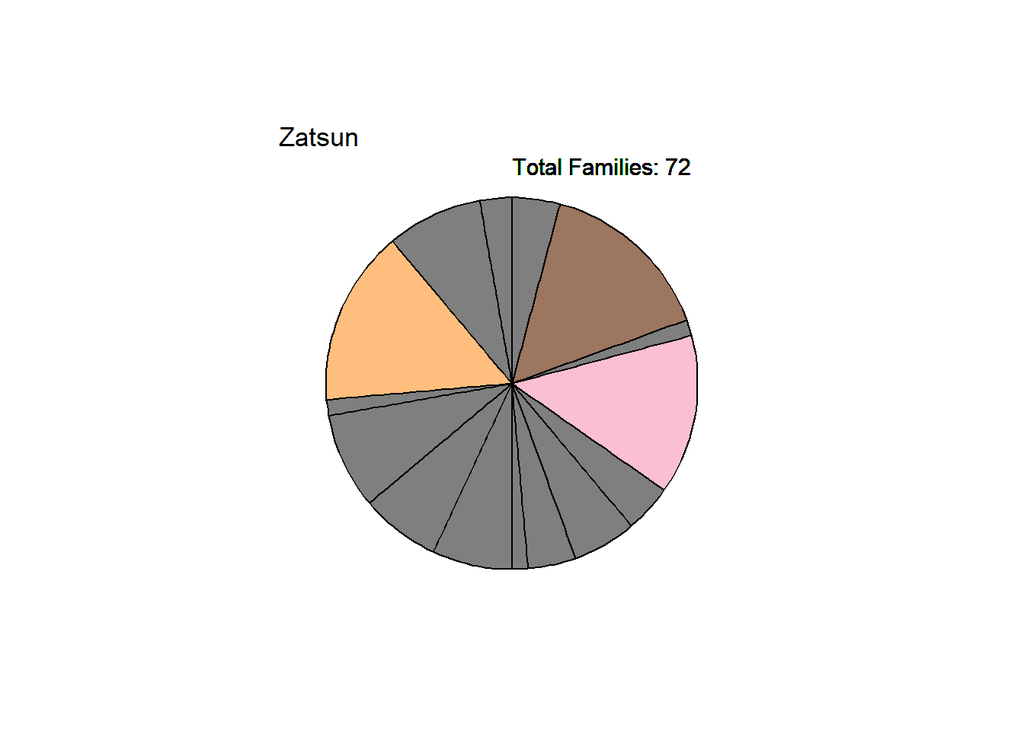

```r
# Check the first pie chart
pie_charts[[12]]
```

Export pie charts per location in folder}

```r
# Create a folder named "piecharts" if it doesn't exist
if (!dir.exists(here("Multi-taxa_data","eDNA", "4-Visualization_outputs","piecharts_site"))) {
  dir.create(here("Multi-taxa_data","eDNA", "4-Visualization_outputs","piecharts_site"))}

# Save the pie charts as images in the "piecharts" folder
lapply(1:length(pie_charts), function(i) {
  ggsave(file = paste0("pie_chart_site_", i, ".png"),
         plot = pie_charts[[i]],
         path = here("Multi-taxa_data","eDNA", "4-Visualization_outputs","piecharts_site")
         )
  }
  )
```

```
## [[1]]
## [1] "C:/Users/claud/Documents/COMUNE/STUDIO_LAVORO/IMBRSea/Thesis/StatAnalysis/Multi-taxa_data/eDNA/4-Visualization_outputs/piecharts_site/pie_chart_site_1.png"
##
## [[2]]
## [1] "C:/Users/claud/Documents/COMUNE/STUDIO_LAVORO/IMBRSea/Thesis/StatAnalysis/Multi-taxa_data/eDNA/4-Visualization_outputs/piecharts_site/pie_chart_site_2.png"
##
## [[3]]
## [1] "C:/Users/claud/Documents/COMUNE/STUDIO_LAVORO/IMBRSea/Thesis/StatAnalysis/Multi-taxa_data/eDNA/4-Visualization_outputs/piecharts_site/pie_chart_site_3.png"
##
## [[4]]
## [1] "C:/Users/claud/Documents/COMUNE/STUDIO_LAVORO/IMBRSea/Thesis/StatAnalysis/Multi-taxa_data/eDNA/4-Visualization_outputs/piecharts_site/pie_chart_site_4.png"
##
## [[5]]
## [1] "C:/Users/claud/Documents/COMUNE/STUDIO_LAVORO/IMBRSea/Thesis/StatAnalysis/Multi-taxa_data/eDNA/4-Visualization_outputs/piecharts_site/pie_chart_site_5.png"
##
## [[6]]
## [1] "C:/Users/claud/Documents/COMUNE/STUDIO_LAVORO/IMBRSea/Thesis/StatAnalysis/Multi-taxa_data/eDNA/4-Visualization_outputs/piecharts_site/pie_chart_site_6.png"
##
## [[7]]
## [1] "C:/Users/claud/Documents/COMUNE/STUDIO_LAVORO/IMBRSea/Thesis/StatAnalysis/Multi-taxa_data/eDNA/4-Visualization_outputs/piecharts_site/pie_chart_site_7.png"
##
## [[8]]
## [1] "C:/Users/claud/Documents/COMUNE/STUDIO_LAVORO/IMBRSea/Thesis/StatAnalysis/Multi-taxa_data/eDNA/4-Visualization_outputs/piecharts_site/pie_chart_site_8.png"
##
## [[9]]
## [1] "C:/Users/claud/Documents/COMUNE/STUDIO_LAVORO/IMBRSea/Thesis/StatAnalysis/Multi-taxa_data/eDNA/4-Visualization_outputs/piecharts_site/pie_chart_site_9.png"
##
## [[10]]
## [1] "C:/Users/claud/Documents/COMUNE/STUDIO_LAVORO/IMBRSea/Thesis/StatAnalysis/Multi-taxa_data/eDNA/4-Visualization_outputs/piecharts_site/pie_chart_site_10.png"
##
## [[11]]
## [1] "C:/Users/claud/Documents/COMUNE/STUDIO_LAVORO/IMBRSea/Thesis/StatAnalysis/Multi-taxa_data/eDNA/4-Visualization_outputs/piecharts_site/pie_chart_site_11.png"
##
## [[12]]
## [1] "C:/Users/claud/Documents/COMUNE/STUDIO_LAVORO/IMBRSea/Thesis/StatAnalysis/Multi-taxa_data/eDNA/4-Visualization_outputs/piecharts_site/pie_chart_site_12.png"
```

# Venn diagram of ESVs by pressure level

Format data

```r
ok_venn_df <- (Okinawa_Tax$ID)

Ok_merge_impact <- merge_samples(Ok, "impact")
Ok_merge_impact_melt <- psmelt(Ok_merge_impact)

Ok_esv_impact_venn <- Ok_merge_impact_melt[,c(1:3)]
Ok_esv_impact_venn <- subset(Ok_esv_impact_venn,
                             Ok_esv_impact_venn$Abundance != 0) # delete rows w/ abundance=0
Ok_esv_impact_venn <- Ok_esv_impact_venn[,-3] # remove abundance
```

Create object with ESVs by impact

```r
esv_high <- subset(Ok_esv_impact_venn,
                   Ok_esv_impact_venn$Sample== "high")$OTU
esv_low <- subset(Ok_esv_impact_venn,
                  Ok_esv_impact_venn$Sample== "low")$OTU
esv_medium <- subset(Ok_esv_impact_venn,
                     Ok_esv_impact_venn$Sample== "medium")$OTU

esv_venn_list <- list(low = esv_low,
                      medium = esv_medium,
                      high = esv_high
)
```

Venn diagram with `ggvenn`

```r
#install.packages("ggvenn")
library(ggvenn)
ggvenn(
  esv_venn_list,
  fill_color = c("#009F81", "#FFB331", "#9F1111"),
  stroke_size = 0.5, set_name_size = 4
)
```

[figure not shown]

Venn diagram with `eulerr`

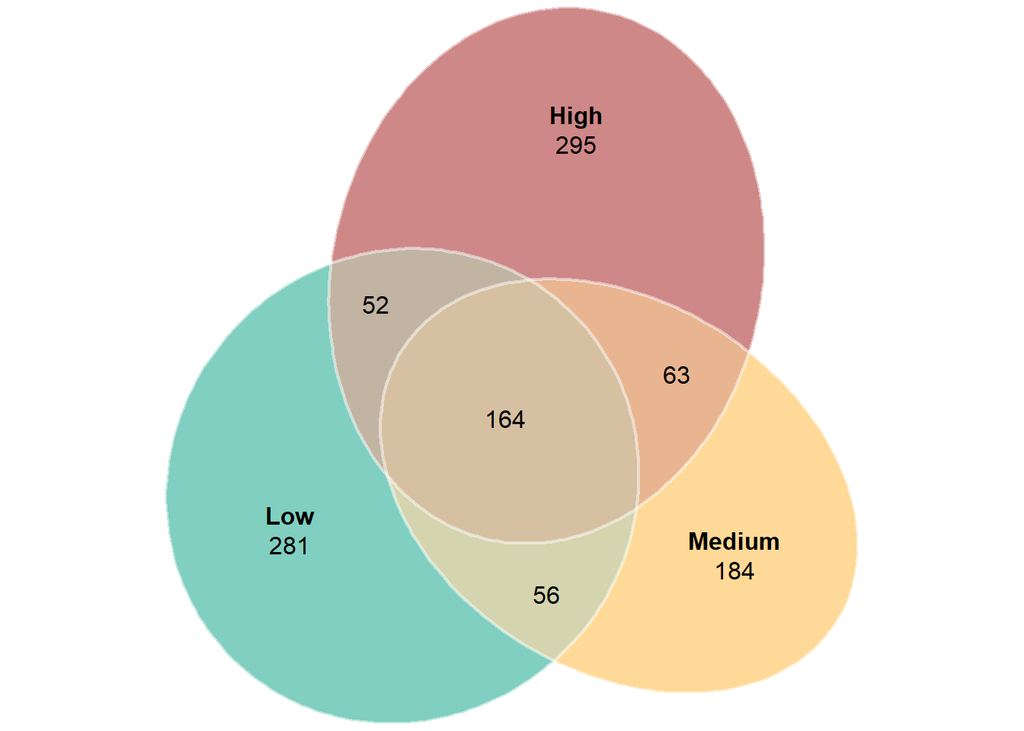

```r
#install.packages("eulerr")
library(eulerr)
esv_venn_extracted <- euler(c("Low" = 281,
                              "Medium" = 184,
                              "High" = 295,
                              "Low&High" = 52,
                              "Low&Medium" = 56,
                              "Medium&High" = 63,
                              "Low&Medium&High" = 164),
                            shape = "ellipse"
)

esv_impact_venn <- plot(esv_venn_extracted,
                        quantities = list(type = "counts"),
                        fill = c(low = "#009F81", medium = "#FFB331",high = "#9F1111"),alpha = 0.5,
                        edges = list(col = "white",
                                     alpha = 0,
                                     lex = 2))

esv_impact_venn
```

```r
ggsave("esv_impact_venn.png",
       plot = esv_impact_venn,
       units ="in", width = 8, height = 6, dpi = 300,
       path = here::here("Multi-taxa_data","eDNA","4-Visualization_outputs"))
```

Venn diagram with `ggVennDiagram`

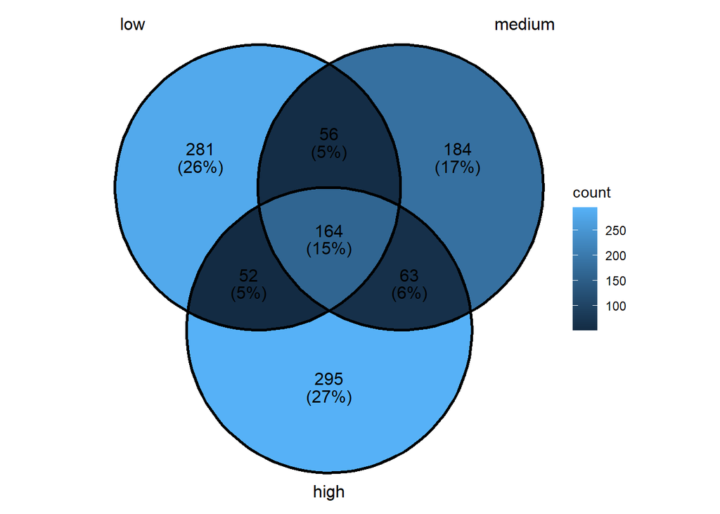

```r
library(ggVennDiagram)
ggVennDiagram::ggVennDiagram(esv_venn_list, label_alpha = 0)
```

# ANCOMBC (Analysis of Compositions of Microbiomes with Bias Correction 2 (ANCOM-BC2) for differential abundance of groups

## ANCOM-BC2 at phylum level

Change reference level to impact = “low”

```r
Ok@sam_data[["impact"]] <- factor(Ok@sam_data[["impact"]], levels = c("low", "medium", "high"))
```

Load required package for ANCOM-BC2

```r
#If needed, install BiocManager and ANCOMBC (by changing chunk settings to eval = T)

if (!require("BiocManager", quietly = TRUE))
  install.packages("BiocManager")
BiocManager::install(version = "3.21")

BiocManager::install("ANCOMBC")

devtools::install_github("FrederickHuangLin/ANCOMBC")

if (!requireNamespace("BiocManager", quietly=TRUE))
    install.packages("BiocManager")
BiocManager::install("ANCOMBC")
```

Run ANCOM-BC2

```r
library(ANCOMBC)

out = ancombc2(Ok,
               tax_level = "Phylum",
               pseudo_sens = FALSE,
               fix_formula = "impact",
               p_adj_method = "holm",
               s0_perc = 0.05,
               prv_cut = 0.10,
               lib_cut = 0,
               group = "impact",
               alpha = 0.05,
               verbose = TRUE,
               global = TRUE,
               pairwise = TRUE)
```

```
## Checking the input data type ...
```

```
## The input data is of type: phyloseq
```

```
## PASS
```

```
## Checking the sample metadata ...
```

```
## The specified variables in the formula: impact
```

```
## The available variables in the sample metadata: Location, depth, impact, pop_score, freshwater_input, fishing_pressure, coast_score, human_score, herma_score, other_pressures
```

```
## PASS
```

```
## Checking other arguments ...
```

```
## The number of groups of interest is: 3
```

```
## The sample size per group is: low = 17, medium = 23, high = 27
```

```
## PASS
```

```
## Obtaining initial estimates ...
```

```
## Estimating sample-specific biases ...
```

```
## ANCOM-BC2 primary results ...
```

```
## ANCOM-BC2 global test ...
```

```
## ANCOM-BC2 multiple pairwise comparisons ...
```

```
## Sensitivity analysis is currently turned off.
## Since sensitivity analysis is essential for reducing false positives,
## it is highly recommended to enable it unless your primary focus is power.
## Are you sure you want to proceed without it?
```

```r
res_prim = out$res
res_global = out$res_global
res_pair = out$res_pair
row.names(res_pair)<-res_prim$taxon
res_dunn = out$res_dunn
res_trend = out$res_trend
pseudo_sens = out$pseudo_sens_tab
```

Remove genera having no significant p-values among comparisons

```r
any_true_impact <- res_pair$diff_impactmedium == TRUE|
  res_pair$diff_impacthigh == TRUE|
  res_pair$diff_impacthigh_impactmedium == TRUE

res_pair_impact <- filter(res_pair,any_true_impact)
```

```r
### ）
PG_mediumvslow <- data.frame(res_pair$W_impactmedium,
                             res_pair$q_impactmedium,
                             row.names = res_pair$taxon) %>%
  rename("W_statistics" = res_pair.W_impactmedium,
         "q_value" = res_pair.q_impactmedium) %>%
  mutate(comparison = "Impact\nlow_vs_medium",
         star=ifelse(q_value<.001, "***",
                     ifelse(q_value<.01, "**",
                            ifelse(q_value<.05, "*", ""))))

PG_highvslow <- data.frame(res_pair$W_impacthigh,
                           res_pair$q_impacthigh,
                           row.names = res_pair$taxon) %>%
  rename("W_statistics" = res_pair.W_impacthigh,
         "q_value" = res_pair.q_impacthigh)%>%
  mutate(comparison = "Impact\nlow_vs_high",
         star=ifelse(q_value<.001, "***",
                     ifelse(q_value<.01, "**",
                            ifelse(q_value<.05, "*", ""))))

PG_mediumvshigh <- data.frame(res_pair$W_impacthigh_impactmedium,
                              res_pair$q_impacthigh_impactmedium,
                              row.names = res_pair$taxon) %>%
  rename("W_statistics" = res_pair.W_impacthigh_impactmedium,
         "q_value" = res_pair.q_impacthigh_impactmedium)%>%
  mutate(comparison = "Impact\nmedium_vs_high",
         star=ifelse(q_value<.001, "***",
                     ifelse(q_value<.01, "**",
                            ifelse(q_value<.05, "*", ""))))

#Combine dataframes into a dataframe, and set impact as factor

df_ancom_impact <- rbind(PG_mediumvslow,PG_highvslow,PG_mediumvshigh) %>%
  mutate(taxon = rep(rownames(PG_mediumvslow),3))
df_ancom_impact$comparison <- factor(df_ancom_impact$comparison,levels = c("Impact\nlow_vs_medium","Impact\nlow_vs_high","Impact\nmedium_vs_high"))

df_ancom_impact$taxon <- factor(df_ancom_impact$taxon,levels = rev(rownames(PG_mediumvslow)))
```

Extract taxonomy information from phyloseq object and merge it the data frame

```r
taxonomy <- as.data.frame(phyloseq::tax_table(Ok))
taxonomy$ESVs <- rownames(taxonomy)

# Merge taxonomy with dataframe
df_ancom_impact_taxon <- merge(df_ancom_impact, taxonomy, by.x = "taxon", by.y = "ESVs", all.x = TRUE)
```

Bar plot of W_statistics by pressure level

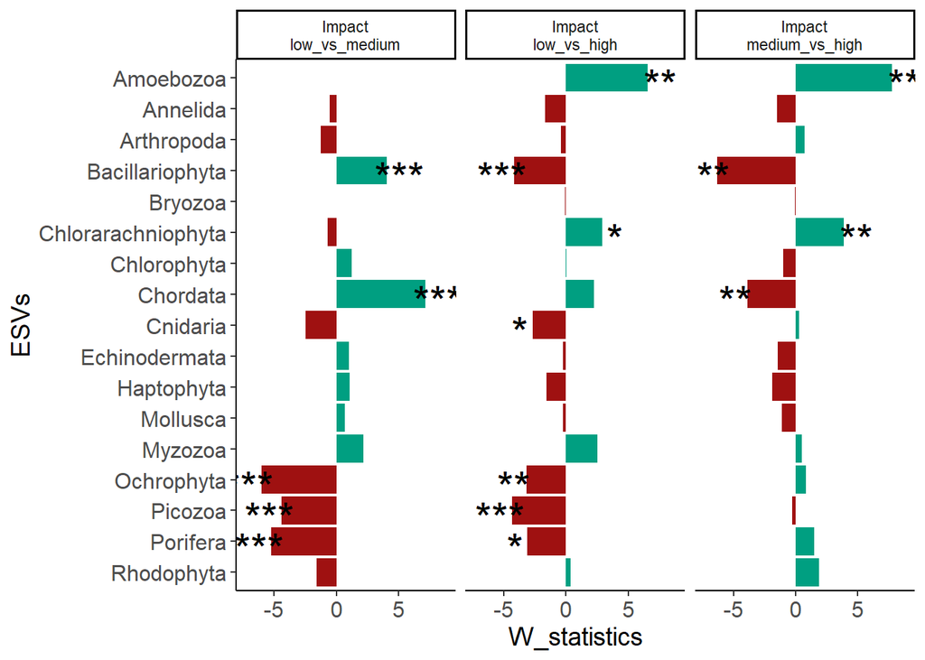

```r
bar_ancom_impact <- df_ancom_impact_taxon %>%
  ggplot(aes(x = taxon, y = W_statistics)) +
  geom_col(aes(fill = factor(ifelse(W_statistics > 0, "Positive", "Negative"))),
           linewidth = 5) +
  labs(x = "ESVs", y = "W_statistics") +
  facet_grid(. ~ comparison,
             labeller = labeller(. = c("pressure /n low vs medium pressure", "low vs high pressure", "medium vs high")
  )) +
  geom_text(aes(y = W_statistics + 1 * sign(W_statistics), label = star), vjust = 0.7, color = "black", size = 8, position = position_dodge(width = 0.5)) +
  theme_classic() +
  theme(legend.position = "none",
        axis.text.x = element_text(size = 12),  # Adjusts the size of x-axis labels
        axis.text.y = element_text(size = 12),  # Adjusts the size of y-axis labels
        axis.title.x = element_text(size = 14), # Adjusts the size of x-axis title
        axis.title.y = element_text(size = 14)) + # Adjusts the size of y-axis title)
  coord_flip() +
  scale_fill_manual(values = c("Positive" = "#009F81", "Negative" = "#9F1111"))

bar_ancom_impact
```

ANCOMBC plot of phyla

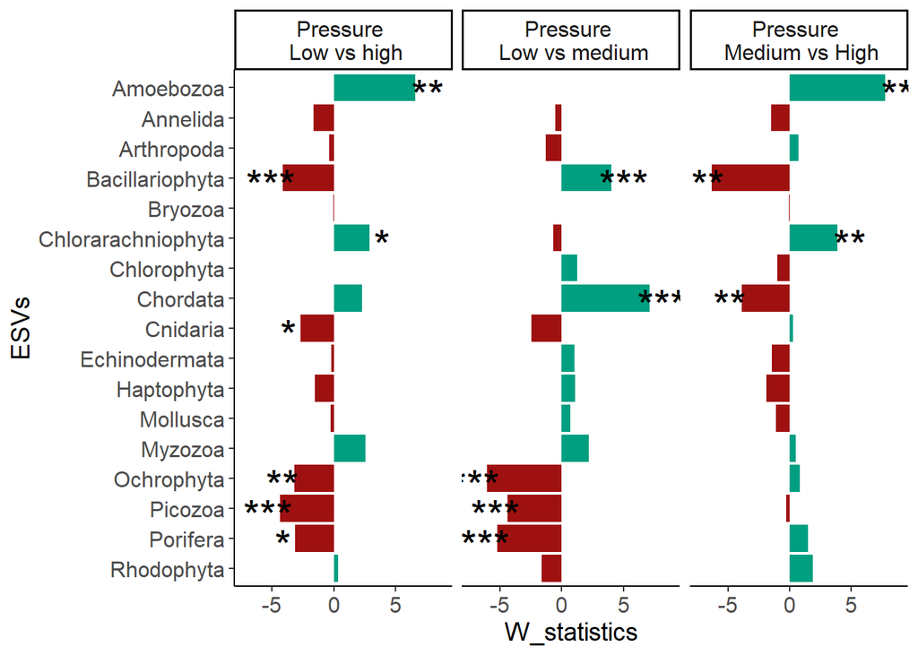

```r
df_ancom_impact_taxon_mod <- df_ancom_impact_taxon %>%
  mutate(comparison = case_when(comparison == "Impact\nlow_vs_medium" ~ "Pressure \n Low vs medium",
                              comparison == "Impact\nlow_vs_high" ~ "Pressure \n Low vs high",
                              comparison == "Impact\nmedium_vs_high"~ "Pressure \n Medium vs High"))

bar_ancom_impact <- "NULL"
bar_ancom_impact <- df_ancom_impact_taxon_mod %>%
  ggplot(aes(x = taxon, y = W_statistics)) +
  geom_col(aes(fill = factor(ifelse(W_statistics > 0, "Positive", "Negative"))),linewidth = 5) +
  labs(x = "ESVs", y = "W_statistics") +
  facet_grid(. ~ comparison)+
  geom_text(aes(y = W_statistics + 1 * sign(W_statistics), label = star),
            vjust = 0.7, color = "black", size = 8, position = position_dodge(width = 0.5)) +
  theme_classic() +
  theme(legend.position = "none",
        axis.text.x = element_text(size = 12),  # Adjusts the size of x-axis labels
        axis.text.y = element_text(size = 12),  # Adjusts the size of y-axis labels
        axis.title.x = element_text(size = 14), # Adjusts the size of x-axis title
        axis.title.y = element_text(size = 14),
        strip.text.x = element_text(size = 12)) + # Adjusts the size of y-axis title)
  coord_flip() +
  scale_fill_manual(values = c("Positive" = "#009F81", "Negative" = "#9F1111"))

bar_ancom_impact
```

Export ANCOM-BC2 plot

```r
ggsave("ANCOM-BC2_period_esv.tiff",
       plot = bar_ancom_impact,
       units="in", width=16, height=12, dpi=300, compression = 'lzw',
       path = here ("Multi-taxa_data","eDNA","4-Visualization_outputs"))

ggsave("ANCOM-BC2_period_esv.png",
       plot = bar_ancom_impact,
       units="in", width=16, height=12, dpi=300,
       path = here ("Multi-taxa_data","eDNA","4-Visualization_outputs"))
```

## ANCOM-BC2 at family level

```r
Ok@sam_data[["impact"]] <- factor(Ok@sam_data[["impact"]],
                                  levels = c("low", "medium", "high"))

out_esv = ancombc2(Ok, tax_level = "Family", pseudo_sens = FALSE, fix_formula = "impact",
                   p_adj_method = "holm", s0_perc = 0.05, prv_cut = 0.10, lib_cut = 0,
                   group = "impact", alpha = 0.05, verbose = TRUE, global = TRUE, pairwise = TRUE)
```

```
## Checking the input data type ...
```

```
## The input data is of type: phyloseq
```

```
## PASS
```

```
## Checking the sample metadata ...
```

```
## The specified variables in the formula: impact
```

```
## The available variables in the sample metadata: Location, depth, impact, pop_score, freshwater_input, fishing_pressure, coast_score, human_score, herma_score, other_pressures
```

```
## PASS
```

```
## Checking other arguments ...
```

```
## The number of groups of interest is: 3
```

```
## The sample size per group is: low = 17, medium = 23, high = 27
```

```
## PASS
```

```
## Obtaining initial estimates ...
```

```
## Estimating sample-specific biases ...
```

```
## ANCOM-BC2 primary results ...
```

```
## ANCOM-BC2 global test ...
```

```
## ANCOM-BC2 multiple pairwise comparisons ...
```

```
## Sensitivity analysis is currently turned off.
## Since sensitivity analysis is essential for reducing false positives,
## it is highly recommended to enable it unless your primary focus is power.
## Are you sure you want to proceed without it?
```

```r
res_prim_esv = out_esv$re
res_global_esv = out_esv$res_global
res_pair_esv = out_esv$res_pair
row.names(res_pair_esv)<-res_prim_esv$taxon
res_dunn_esv = out_esv$res_dunn
res_trend_esv = out_esv$res_trend
pseudo_sens_esv = out_esv$pseudo_sens_tab
```

Remove genera having no significant p-values among comparisons

```r
any_true_impact_esv <- res_pair_esv$q_impactmedium <.05|
  res_pair_esv$q_impacthigh <.05|
  res_pair_esv$q_impacthigh_impactmedium <.05

res_pair_impact_esv <- filter(res_pair_esv,any_true_impact_esv)
```

```r
PG_mediumvslow_esv <- data.frame(res_pair_impact_esv$W_impactmedium,
                                 res_pair_impact_esv$q_impactmedium,
                                 row.names = res_pair_impact_esv$taxon)  %>%
  rename("W_statistics" = res_pair_impact_esv.W_impactmedium,
         "q_value" = res_pair_impact_esv.q_impactmedium)%>%
  mutate(comparison = "Impact\nlow_vs_medium",
         star=ifelse(q_value<.001, "***",
                     ifelse(q_value<.01, "**",
                            ifelse(q_value<.05, "*", ""))))

PG_highvslow_esv <- data.frame(res_pair_impact_esv$W_impacthigh,
                               res_pair_impact_esv$q_impacthigh,
                               row.names = res_pair_impact_esv$taxon) %>%
  rename("W_statistics" = res_pair_impact_esv.W_impacthigh,
         "q_value" = res_pair_impact_esv.q_impacthigh)%>%
  mutate(comparison = "Impact\nlow_vs_high",
         star=ifelse(q_value<.001, "***",
                     ifelse(q_value<.01, "**",
                            ifelse(q_value<.05, "*", ""))))

PG_mediumvshigh_esv <- data.frame(res_pair_impact_esv$W_impacthigh_impactmedium,
                                  res_pair_impact_esv$q_impacthigh_impactmedium,
                                  row.names = res_pair_impact_esv$taxon) %>%
  rename("W_statistics" = res_pair_impact_esv.W_impacthigh_impactmedium,
         "q_value" = res_pair_impact_esv.q_impacthigh_impactmedium)%>%
  mutate(comparison = "Impact\nmedium_vs_high",
         star=ifelse(q_value<.001, "***",
                     ifelse(q_value<.01, "**",
                            ifelse(q_value<.05, "*", ""))))


### Combine dataframes into a dataframe, and set factors impact

df_ancom_impact_esv <-rbind(PG_mediumvslow_esv,
                            PG_highvslow_esv,
                            PG_mediumvshigh_esv) %>%
  mutate(taxon = rep(rownames(PG_mediumvslow_esv),3))

df_ancom_impact_esv$comparison <- factor(df_ancom_impact_esv$comparison,
                                         levels = c("Impact\nlow_vs_medium",
                                                    "Impact\nlow_vs_high",
                                                    "Impact\nmedium_vs_high"))

df_ancom_impact_esv$taxon <- factor(df_ancom_impact_esv$taxon,
                                    levels = rev(rownames(PG_mediumvslow_esv)))
```

Extract taxonomy information from phyloseq object

```r
taxonomy_esv <- as.data.frame(tax_table(Ok))
taxonomy_esv$ESVs <- rownames(taxonomy_esv)

### Merge taxonomy with dataframe
df_ancom_impact_taxon_esv <- merge(df_ancom_impact_esv, taxonomy_esv, by.x = "taxon", by.y = "ESVs", all.x = TRUE)
```

ANCOMBC plot of family

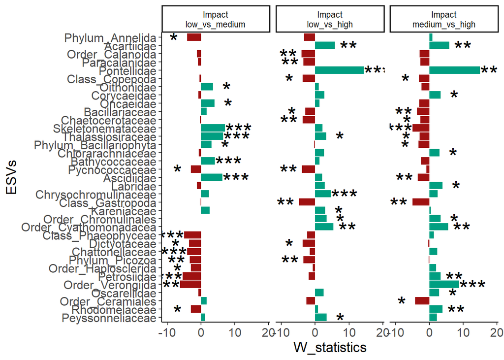

```r
bar_ancom_impact_esv_family <- df_ancom_impact_taxon_esv %>%
  ggplot(aes(x = taxon, y = W_statistics)) +
  geom_col(aes(fill = factor(ifelse(W_statistics > 0, "Positive", "Negative"))),linewidth = 5) +
  labs(x = "ESVs", y = "W_statistics") +
  facet_grid(. ~ comparison) +
  geom_text(aes(y = W_statistics + 4 * sign(W_statistics), label = star),
            vjust = 0.7, color = "black", size = 8, position = position_dodge(width = 0.5)) +
  theme_classic() +
  theme(legend.position = "none",
        axis.text.x = element_text(size = 12),  # Adjusts the size of x-axis labels
        axis.text.y = element_text(size = 12),  # Adjusts the size of y-axis labels
        axis.title.x = element_text(size = 14), # Adjusts the size of x-axis title
        axis.title.y = element_text(size = 14)) + # Adjusts the size of y-axis title)
  coord_flip() +
  scale_fill_manual(values = c("Positive" = "#009F81", "Negative" = "#9F1111"))

bar_ancom_impact_esv_family
```

Export ANCOM-BC2 plot of families

```r
ggsave("ANCOM-BC2_period_Family.tiff",
       plot = bar_ancom_impact_esv_family,
       units="in", width=10, height=8, dpi=300, compression = 'lzw',
       path = here ("Multi-taxa_data","eDNA","4-Visualization_outputs"))

ggsave("ANCOM-BC2_period_Family.png",
       plot = bar_ancom_impact_esv_family,
       units="in", width=10, height=6, dpi=300,
       path = here ("Multi-taxa_data","eDNA","4-Visualization_outputs"))
```